# Results Plots Final2

Sean Dimoff

30/1/2020

**Exploratory Plots for 2017-2018 Acoustic/Fish Data**

**Purpose** To explore the Acoustic data gathered in 2017 and 2018 to expose important trends between sites, diurnal patterns, fish abundance, lunar phase, and coral reef acoustics.

# Validations

**Combined Model** All variables are matched to the files that were used for Fish call counts (3:00, 9:00, 15:00, 21:00)

## Confidence Intervals

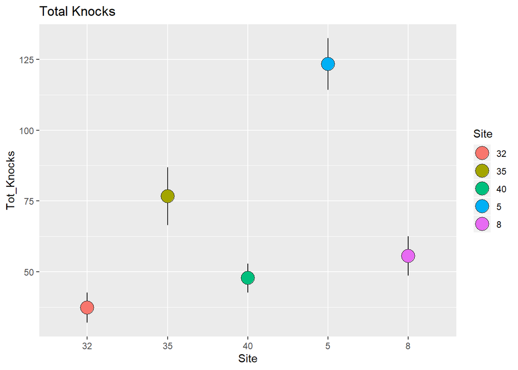

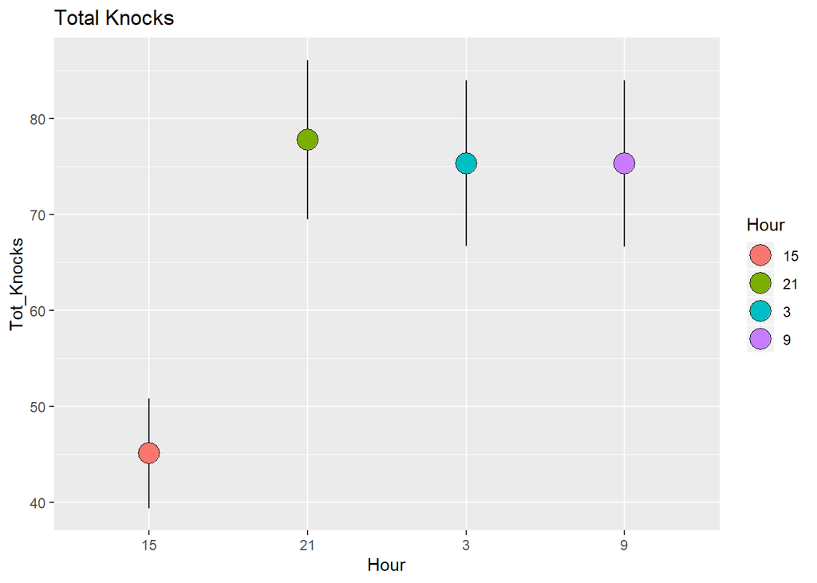

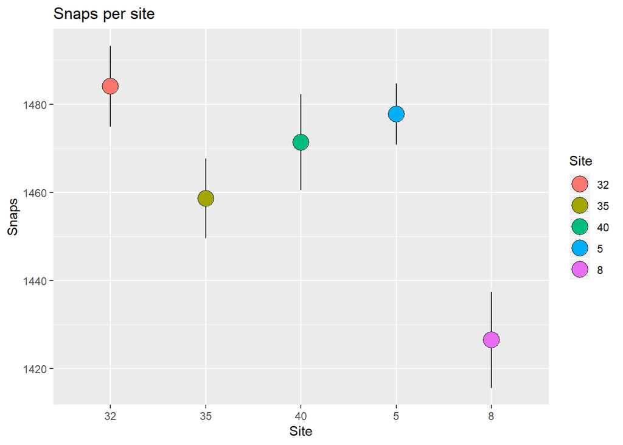

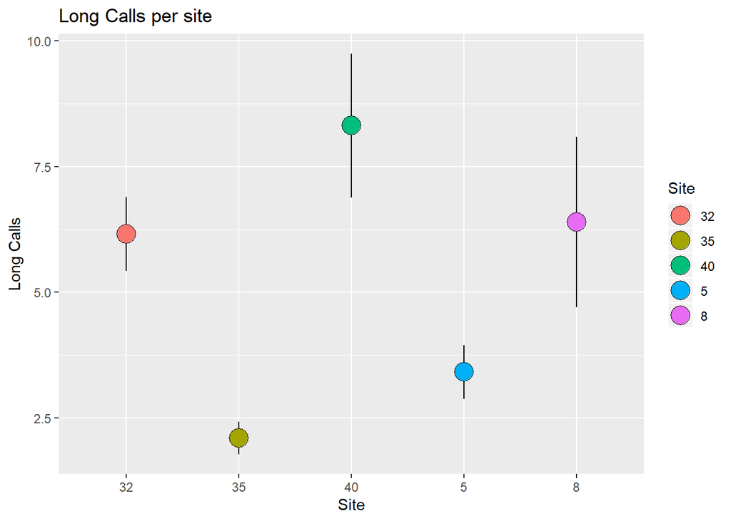

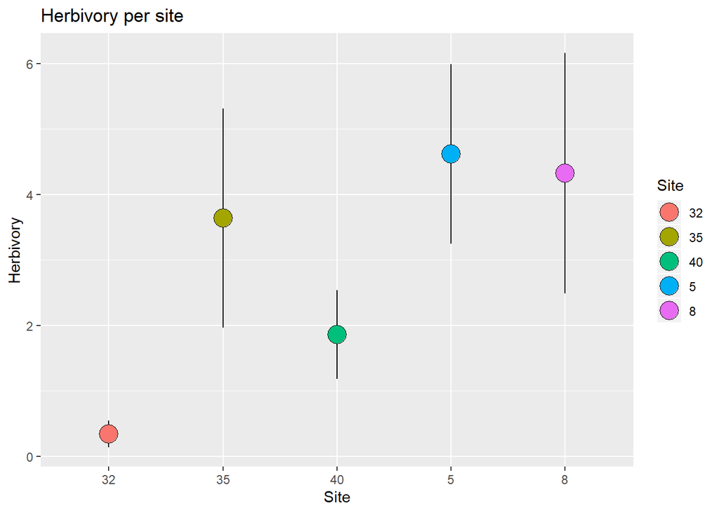

## Distributions

Red is the Mean Line

Blue is the Median Line

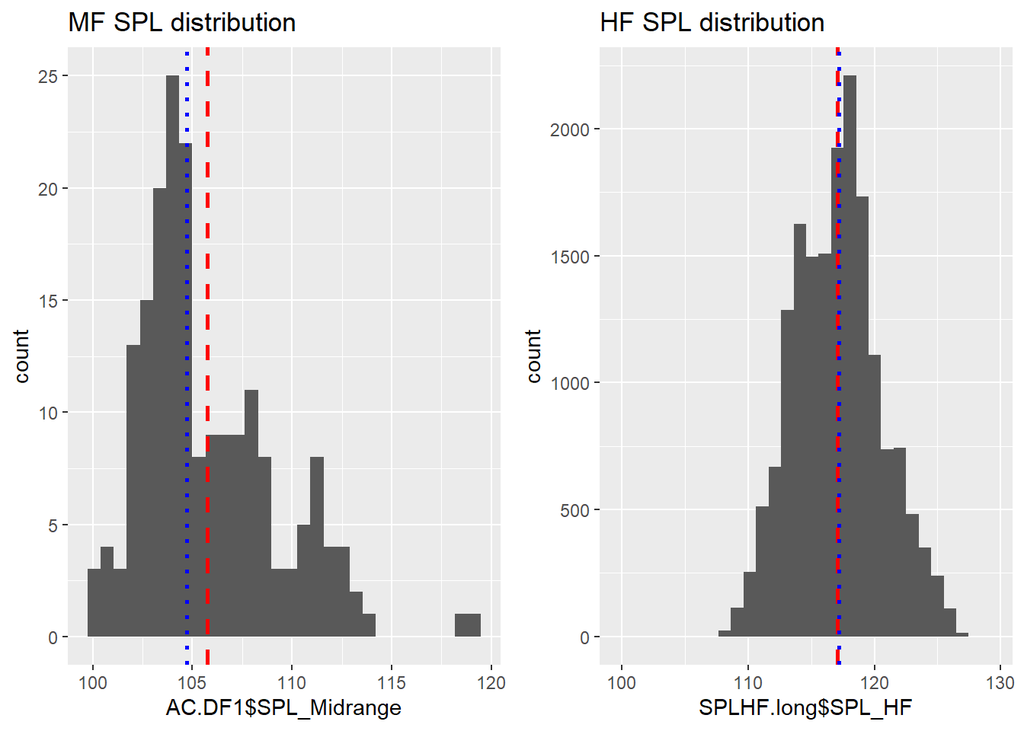

Stats for Mid Frequency SPL

```
##    Min. 1st Qu.  Median    Mean 3rd Qu.    Max.
##   100.2   103.4   104.7   105.8   107.7   119.3
```

Variance of MF

```
## [1] 11.87399
```

Stats for High Frequency SPL

```
##    Min. 1st Qu.  Median    Mean 3rd Qu.    Max.
##   100.4   114.5   117.2   117.1   119.2   129.1
```

Variance of HF

```
## [1] 11.96909
```

ACI histogram

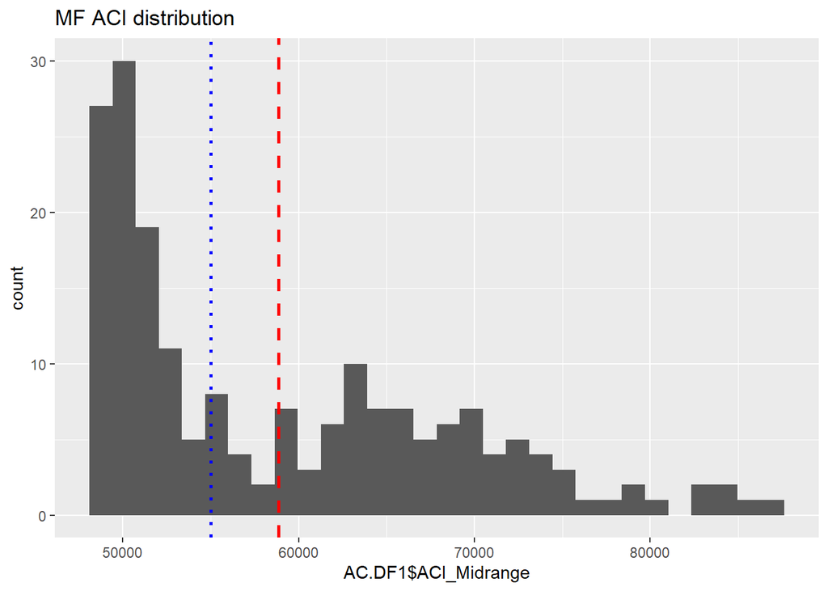

## Regressions

Running basic regressions linking the explanatory to the response at their lowest levels and combined to see how different sites/ hours change the regression - SPL

**Linear Model outputs below each**

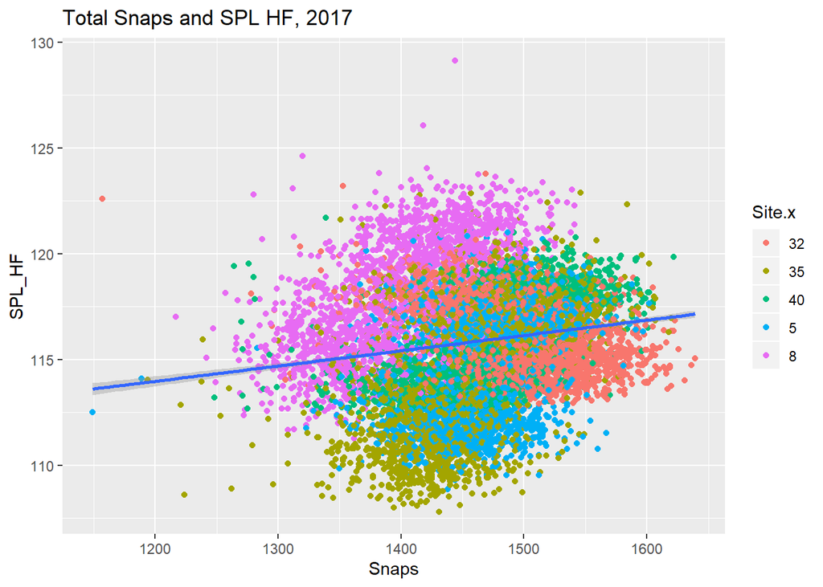

```
##
## Call:
## lm(formula = SPL_HF ~ Snaps, data = Snap.HF17)
##
## Residuals:
##     Min      1Q  Median      3Q     Max
## -7.8309 -1.9842  0.2062  1.8451 13.3944
##
## Coefficients:
##              Estimate Std. Error t value Pr(>|t|)
## (Intercept) 1.053e+02  6.541e-01  160.99   <2e-16 ***
## Snaps       7.227e-03  4.475e-04   16.15   <2e-16 ***
## ---
## Signif. codes:  0 '***' 0.001 '**' 0.01 '*' 0.05 '.' 0.1 ' ' 1
##
## Residual standard error: 2.807 on 10163 degrees of freedom
## Multiple R-squared:  0.02502,    Adjusted R-squared:  0.02493
## F-statistic: 260.8 on 1 and 10163 DF,  p-value: < 2.2e-16
```

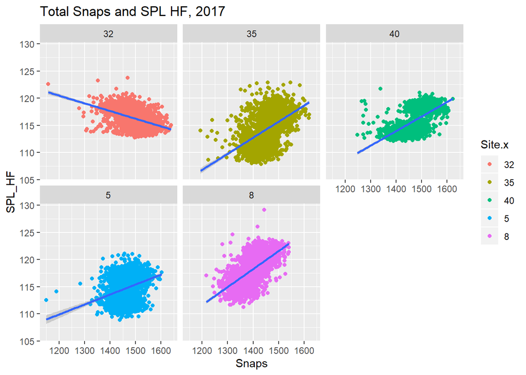

2017 Snap data, snaps significant.

When you break it down by site, site 32 has the opposite relationship with high frequency and snaps.

### High Frequency

**2017 Snap/HF SPL Site Breakdown**

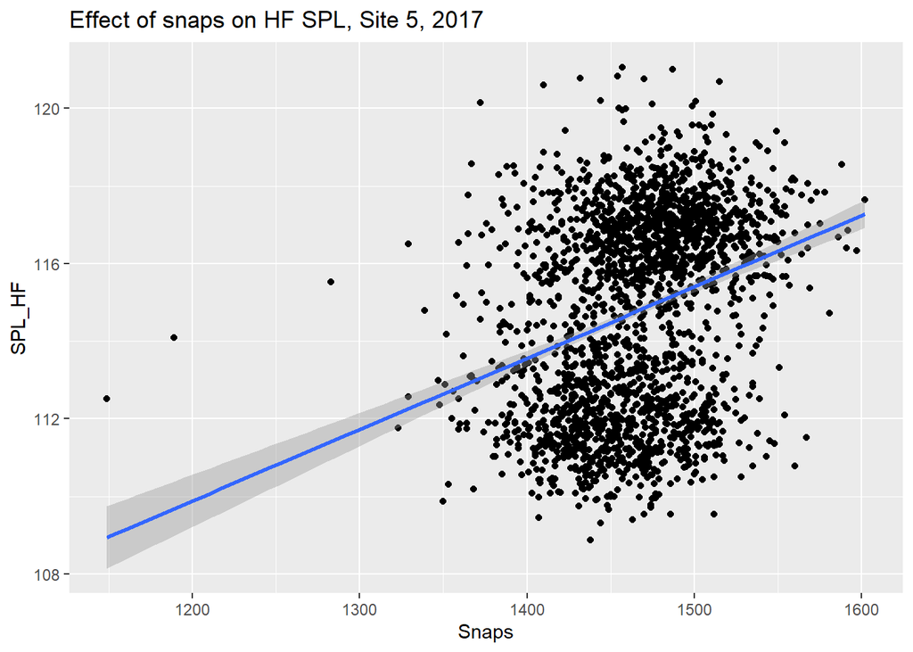

```
##
## Call:
## lm(formula = SPL_HF ~ Snaps, data = s17s5)
##
## Residuals:
##     Min      1Q  Median      3Q     Max
## -6.0817 -2.1540  0.4371  1.9805  7.0937
##
## Coefficients:
##              Estimate Std. Error t value Pr(>|t|)
## (Intercept) 87.830664   1.873329   46.88   <2e-16 ***
## Snaps        0.018381   0.001277   14.39   <2e-16 ***
## ---
## Signif. codes:  0 '***' 0.001 '**' 0.01 '*' 0.05 '.' 0.1 ' ' 1
##
## Residual standard error: 2.483 on 2101 degrees of freedom
## Multiple R-squared:  0.08971,    Adjusted R-squared:  0.08928
## F-statistic: 207.1 on 1 and 2101 DF,  p-value: < 2.2e-16
```

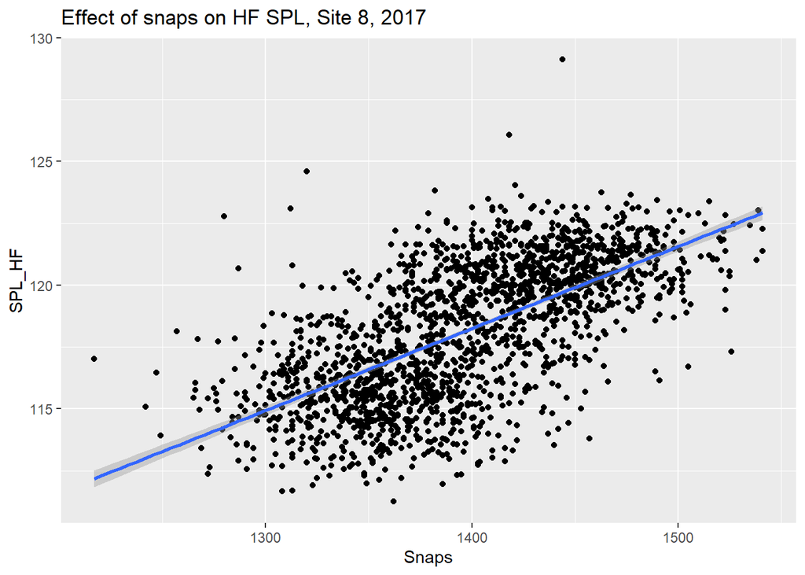

```
##
## Call:
## lm(formula = SPL_HF ~ Snaps, data = s17s8)
##
## Residuals:
##     Min      1Q  Median      3Q     Max
## -6.3374 -1.3945  0.1363  1.4230  9.4265
##
## Coefficients:
##              Estimate Std. Error t value Pr(>|t|)
## (Intercept) 7.185e+01  1.270e+00   56.59   <2e-16 ***
## Snaps       3.314e-02  9.084e-04   36.48   <2e-16 ***
## ---
## Signif. codes:  0 '***' 0.001 '**' 0.01 '*' 0.05 '.' 0.1 ' ' 1
##
## Residual standard error: 2.117 on 1831 degrees of freedom
## Multiple R-squared:  0.4209, Adjusted R-squared:  0.4206
## F-statistic:  1331 on 1 and 1831 DF,  p-value: < 2.2e-16
```

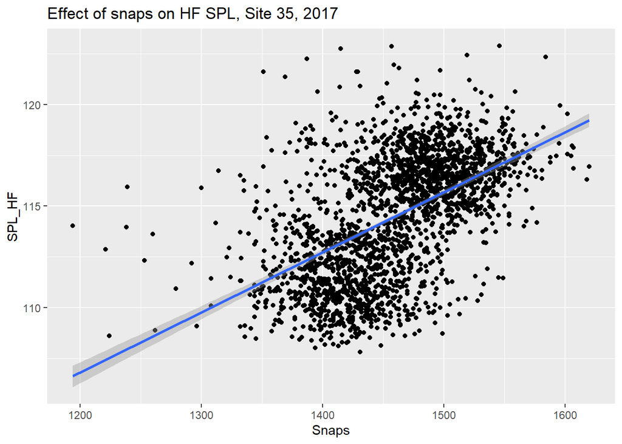

```
##
## Call:
## lm(formula = SPL_HF ~ Snaps, data = s17s35)
##
## Residuals:
##     Min      1Q  Median      3Q     Max
## -6.9213 -1.7565 -0.0424  1.6512 10.3407
##
## Coefficients:
##              Estimate Std. Error t value Pr(>|t|)
## (Intercept) 71.282701   1.451690   49.10   <2e-16 ***
## Snaps        0.029598   0.000995   29.75   <2e-16 ***
## ---
## Signif. codes:  0 '***' 0.001 '**' 0.01 '*' 0.05 '.' 0.1 ' ' 1
##
## Residual standard error: 2.573 on 2205 degrees of freedom
## Multiple R-squared:  0.2864, Adjusted R-squared:  0.2861
## F-statistic: 884.9 on 1 and 2205 DF,  p-value: < 2.2e-16
```

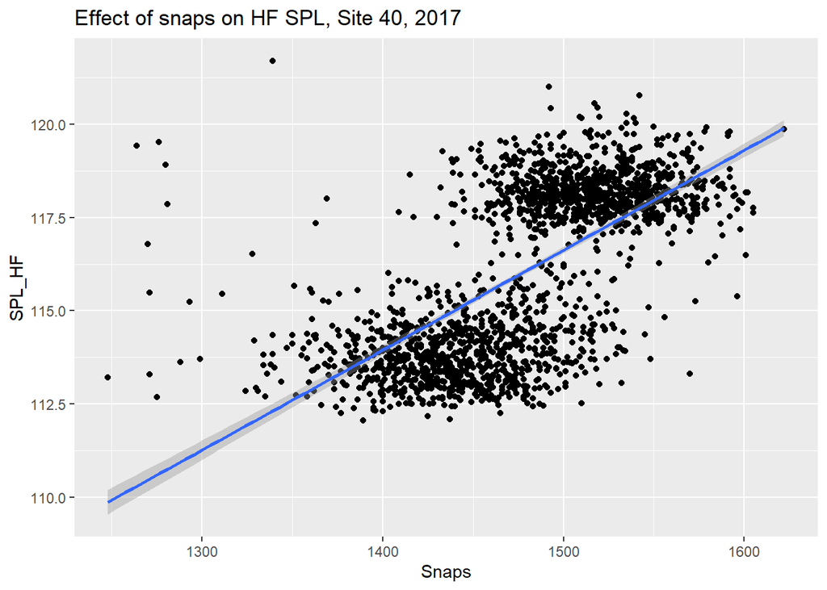

```
##
## Call:
## lm(formula = SPL_HF ~ Snaps, data = s17s40)
##
## Residuals:
##     Min      1Q  Median      3Q     Max
## -5.1902 -1.2312  0.0344  1.2186  9.3897
##
## Coefficients:
##              Estimate Std. Error t value Pr(>|t|)
## (Intercept) 7.644e+01  1.044e+00   73.19   <2e-16 ***
## Snaps       2.679e-02  7.062e-04   37.93   <2e-16 ***
## ---
## Signif. codes:  0 '***' 0.001 '**' 0.01 '*' 0.05 '.' 0.1 ' ' 1
##
## Residual standard error: 1.736 on 1862 degrees of freedom
## Multiple R-squared:  0.4359, Adjusted R-squared:  0.4356
## F-statistic:  1439 on 1 and 1862 DF,  p-value: < 2.2e-16
```

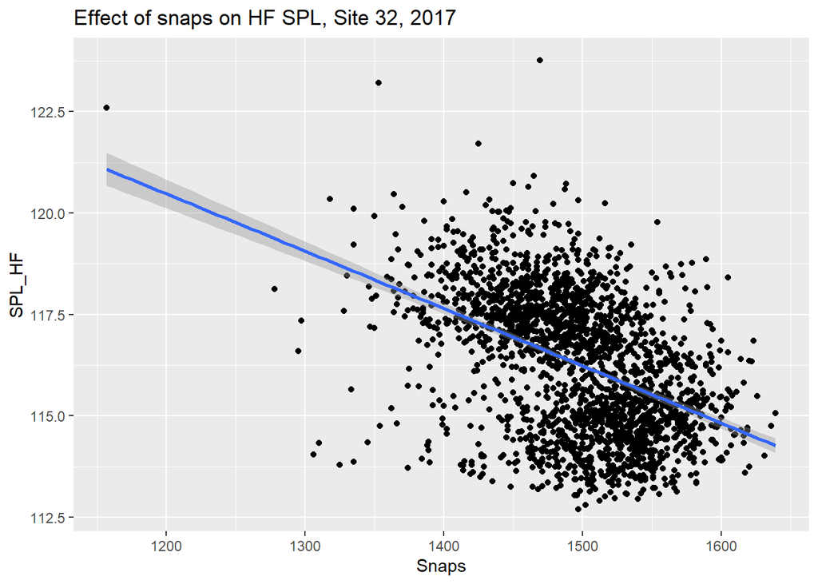

```
##
## Call:
## lm(formula = SPL_HF ~ Snaps, data = s17s32)
##
## Residuals:
##    Min     1Q Median     3Q    Max
## -4.936 -1.084  0.114  1.063  7.102
##
## Coefficients:
##              Estimate Std. Error t value Pr(>|t|)
## (Intercept) 137.43721    0.89844  152.97   <2e-16 ***
## Snaps        -0.01414    0.00060  -23.56   <2e-16 ***
## ---
## Signif. codes:  0 '***' 0.001 '**' 0.01 '*' 0.05 '.' 0.1 ' ' 1
##
## Residual standard error: 1.532 on 2156 degrees of freedom
## Multiple R-squared:  0.2047, Adjusted R-squared:  0.2044
## F-statistic:   555 on 1 and 2156 DF,  p-value: < 2.2e-16
```

**2018 Snap/HF SPL**

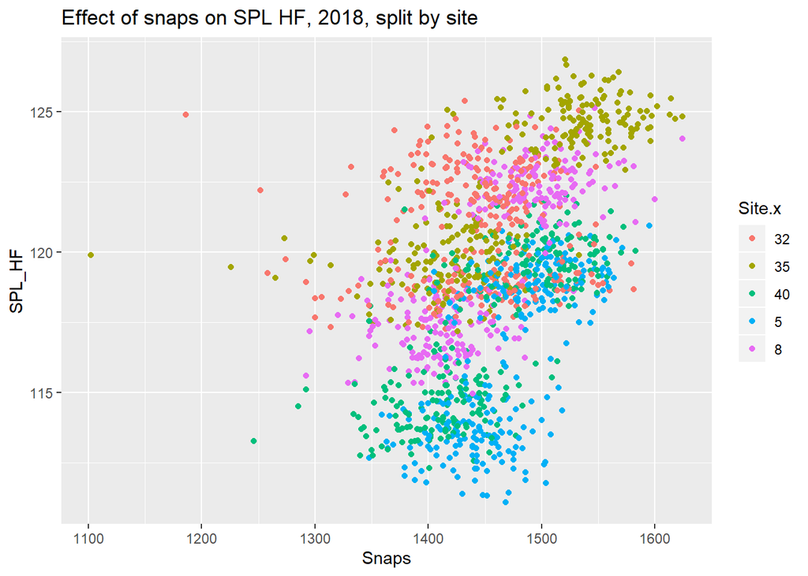

Removing outliers

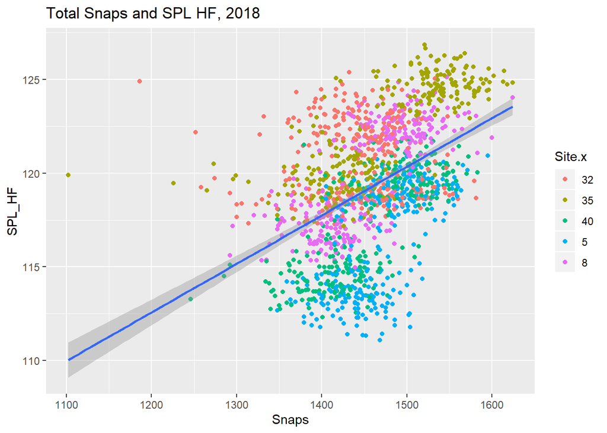

```
##
## Call:
## lm(formula = SPL_HF ~ Snaps, data = Snap.HF18)
##
## Residuals:
##     Min      1Q  Median      3Q     Max
## -8.6746 -2.0071 -0.0087  2.3005 12.6859
##
## Coefficients:
##              Estimate Std. Error t value Pr(>|t|)
## (Intercept) 81.468599   1.919126   42.45   <2e-16 ***
## Snaps        0.025921   0.001315   19.71   <2e-16 ***
## ---
## Signif. codes:  0 '***' 0.001 '**' 0.01 '*' 0.05 '.' 0.1 ' ' 1
##
## Residual standard error: 3.072 on 1453 degrees of freedom
## Multiple R-squared:  0.211,  Adjusted R-squared:  0.2105
## F-statistic: 388.7 on 1 and 1453 DF,  p-value: < 2.2e-16
```

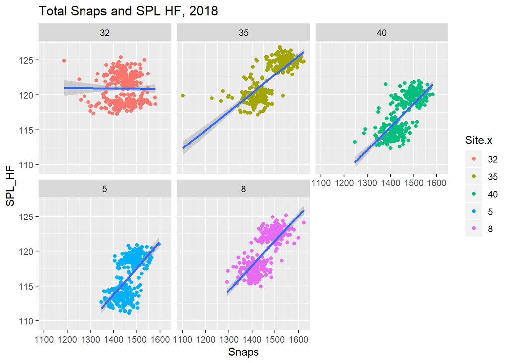

2018 Snap data with outliers removed. Snaps significant.

When split by sight, site 32 has a flat relationship.

**2018 Snap/HF SPL Site Breakdown**

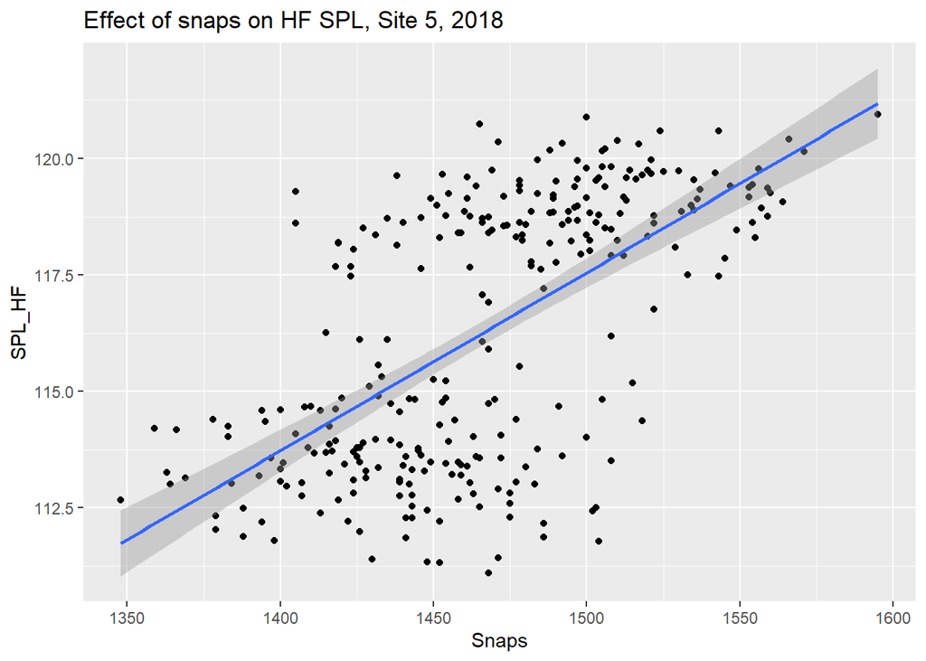

```
##
## Call:
## lm(formula = SPL_HF ~ Snaps, data = s18s5)
##
## Residuals:
##     Min      1Q  Median      3Q     Max
## -5.9245 -1.5844  0.1253  1.6517  5.3652
##
## Coefficients:
##              Estimate Std. Error t value Pr(>|t|)
## (Intercept) 60.225493   4.141984   14.54   <2e-16 ***
## Snaps        0.038216   0.002823   13.54   <2e-16 ***
## ---
## Signif. codes:  0 '***' 0.001 '**' 0.01 '*' 0.05 '.' 0.1 ' ' 1
##
## Residual standard error: 2.238 on 289 degrees of freedom
## Multiple R-squared:  0.388,  Adjusted R-squared:  0.3859
## F-statistic: 183.2 on 1 and 289 DF,  p-value: < 2.2e-16
```

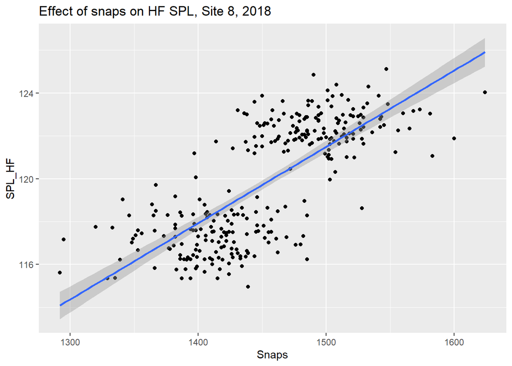

```
##
## Call:
## lm(formula = SPL_HF ~ Snaps, data = s18s8)
##
## Residuals:
##     Min      1Q  Median      3Q     Max
## -4.7323 -1.3490 -0.0334  1.4302  4.1632
##
## Coefficients:
##              Estimate Std. Error t value Pr(>|t|)
## (Intercept) 68.048894   2.745679   24.78   <2e-16 ***
## Snaps        0.035631   0.001889   18.87   <2e-16 ***
## ---
## Signif. codes:  0 '***' 0.001 '**' 0.01 '*' 0.05 '.' 0.1 ' ' 1
##
## Residual standard error: 1.849 on 289 degrees of freedom
## Multiple R-squared:  0.5519, Adjusted R-squared:  0.5504
## F-statistic:   356 on 1 and 289 DF,  p-value: < 2.2e-16
```

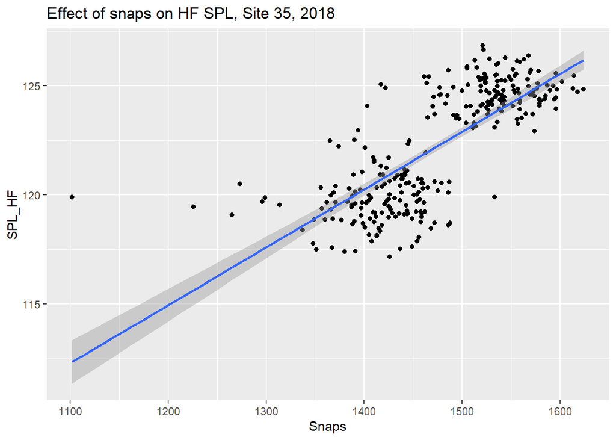

```
##
## Call:
## lm(formula = SPL_HF ~ Snaps, data = s18s35)
##
## Residuals:
##     Min      1Q  Median      3Q     Max
## -3.9232 -1.1784 -0.1059  1.0416  7.5440
##
## Coefficients:
##             Estimate Std. Error t value Pr(>|t|)
## (Intercept) 83.11812    1.96366   42.33   <2e-16 ***
## Snaps        0.02652    0.00133   19.94   <2e-16 ***
## ---
## Signif. codes:  0 '***' 0.001 '**' 0.01 '*' 0.05 '.' 0.1 ' ' 1
##
## Residual standard error: 1.739 on 289 degrees of freedom
## Multiple R-squared:  0.5791, Adjusted R-squared:  0.5776
## F-statistic: 397.6 on 1 and 289 DF,  p-value: < 2.2e-16
```

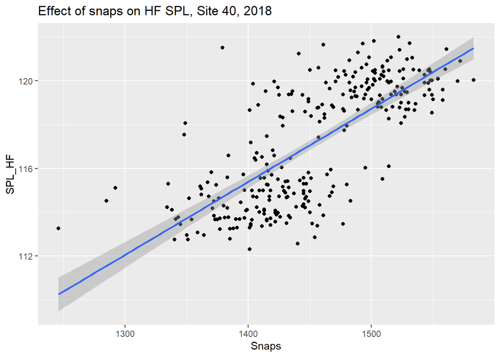

```
##
## Call:
## lm(formula = SPL_HF ~ Snaps, data = s18s40)
##
## Residuals:
##     Min      1Q  Median      3Q     Max
## -4.4914 -1.3764 -0.1106  1.2747  6.8204
##
## Coefficients:
##              Estimate Std. Error t value Pr(>|t|)
## (Intercept) 68.686141   2.640335   26.01   <2e-16 ***
## Snaps        0.033362   0.001816   18.38   <2e-16 ***
## ---
## Signif. codes:  0 '***' 0.001 '**' 0.01 '*' 0.05 '.' 0.1 ' ' 1
##
## Residual standard error: 1.869 on 289 degrees of freedom
## Multiple R-squared:  0.5388, Adjusted R-squared:  0.5372
## F-statistic: 337.7 on 1 and 289 DF,  p-value: < 2.2e-16
```

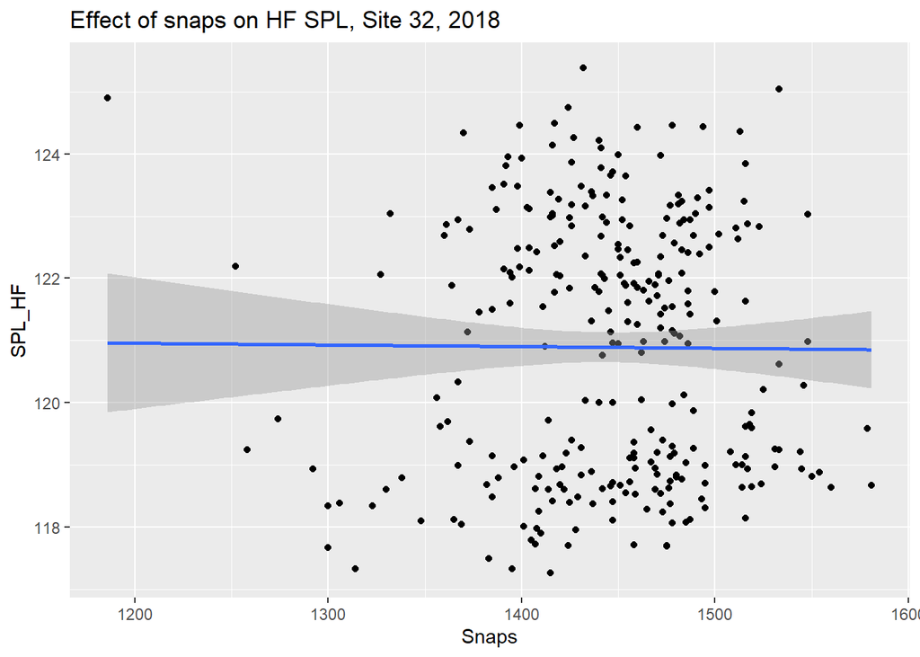

```
##
## Call:
## lm(formula = SPL_HF ~ Snaps, data = s18s32)
##
## Residuals:
##     Min      1Q  Median      3Q     Max
## -3.6331 -1.9735  0.2795  1.8090  4.4940
##
## Coefficients:
##               Estimate Std. Error t value Pr(>|t|)
## (Intercept)  1.213e+02  3.090e+00  39.250   <2e-16 ***
## Snaps       -2.742e-04  2.136e-03  -0.128    0.898
## ---
## Signif. codes:  0 '***' 0.001 '**' 0.01 '*' 0.05 '.' 0.1 ' ' 1
##
## Residual standard error: 2.074 on 289 degrees of freedom
## Multiple R-squared:  5.699e-05,  Adjusted R-squared:  -0.003403
## F-statistic: 0.01647 on 1 and 289 DF,  p-value: 0.898
```

### Mid Frequency

**Mid Frequency - SPL**

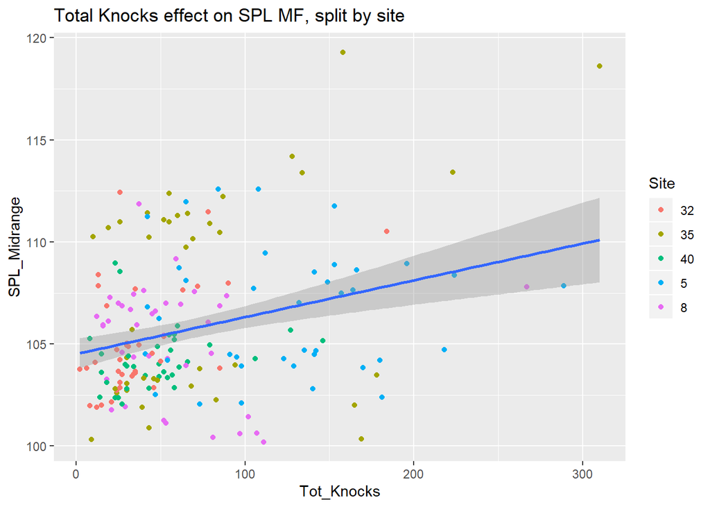

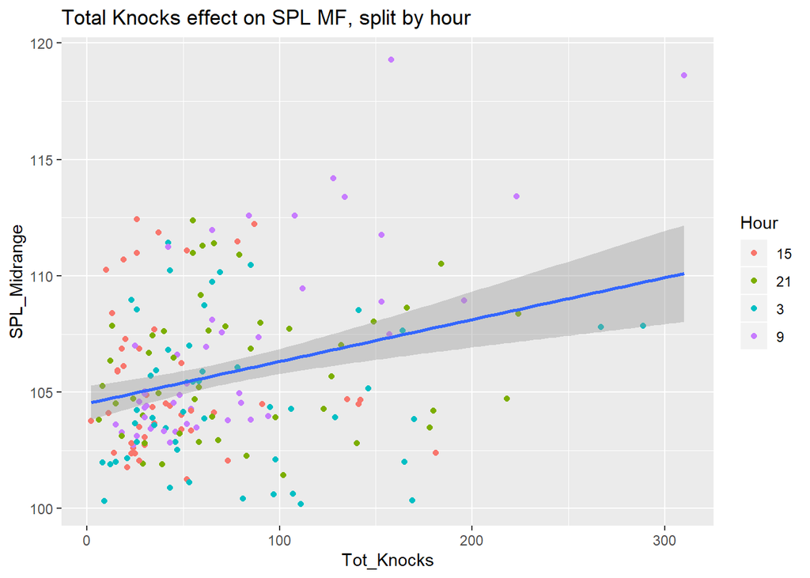

```
##
## Call:
## lm(formula = SPL_Midrange ~ Tot_Knocks, data = AC.DF1)
##
## Residuals:
##     Min      1Q  Median      3Q     Max
## -7.2088 -2.1924 -0.7869  1.6962 11.9299
##
## Coefficients:
##              Estimate Std. Error t value Pr(>|t|)
## (Intercept) 1.045e+02  3.773e-01 277.047  < 2e-16 ***
## Tot_Knocks  1.801e-02  4.252e-03   4.237 3.54e-05 ***
## ---
## Signif. codes:  0 '***' 0.001 '**' 0.01 '*' 0.05 '.' 0.1 ' ' 1
##
## Residual standard error: 3.302 on 189 degrees of freedom
## Multiple R-squared:  0.08674,    Adjusted R-squared:  0.08191
## F-statistic: 17.95 on 1 and 189 DF,  p-value: 3.538e-05
```

**Mid Frequency - ACI**

```
##
## Call:
## glm(formula = ACI_Midrange ~ Tot_Knocks + Year, family = "Gamma",
##     data = AC.DF1)
##
## Deviance Residuals:
##      Min        1Q    Median        3Q       Max
## -0.24710  -0.14537  -0.07297   0.11790   0.40777
##
## Coefficients:
##               Estimate Std. Error t value Pr(>|t|)
## (Intercept)  1.746e-05  3.758e-07  46.459   <2e-16 ***
## Tot_Knocks  -8.617e-09  3.462e-09  -2.489   0.0137 *
## Year18       2.779e-07  4.078e-07   0.682   0.4964
## ---
## Signif. codes:  0 '***' 0.001 '**' 0.01 '*' 0.05 '.' 0.1 ' ' 1
##
## (Dispersion parameter for Gamma family taken to be 0.02745441)
##
##     Null deviance: 4.9867  on 190  degrees of freedom
## Residual deviance: 4.8131  on 188  degrees of freedom
## AIC: 4038.2
##
## Number of Fisher Scoring iterations: 4
```

```
##
## Call:
## glm(formula = ACI_Midrange ~ Num_L_calls + Year, family = "Gamma",
##     data = AC.DF1)
##
## Deviance Residuals:
##      Min        1Q    Median        3Q       Max
## -0.19561  -0.15304  -0.06392   0.11642   0.42225
##
## Coefficients:
##               Estimate Std. Error t value Pr(>|t|)
## (Intercept)  1.690e-05  3.382e-07  49.964   <2e-16 ***
## Num_L_calls -4.017e-09  2.953e-08  -0.136    0.892
## Year18       2.304e-07  4.140e-07   0.557    0.579
## ---
## Signif. codes:  0 '***' 0.001 '**' 0.01 '*' 0.05 '.' 0.1 ' ' 1
##
## (Dispersion parameter for Gamma family taken to be 0.02823657)
##
##     Null deviance: 4.9867  on 190  degrees of freedom
## Residual deviance: 4.9772  on 188  degrees of freedom
## AIC: 4044.6
##
## Number of Fisher Scoring iterations: 4
```

```
##
## Call:
## glm(formula = ACI_Midrange ~ Num_Herbivory + Year, family = "Gamma",
##     data = AC.DF1)
##
## Deviance Residuals:
##      Min        1Q    Median        3Q       Max
## -0.22182  -0.15000  -0.06905   0.11317   0.42714
##
## Coefficients:
##                 Estimate Std. Error t value Pr(>|t|)
## (Intercept)    1.697e-05  3.019e-07  56.198   <2e-16 ***
## Num_Herbivory -2.940e-08  2.290e-08  -1.284    0.201
## Year18         2.350e-07  4.112e-07   0.571    0.568
## ---
## Signif. codes:  0 '***' 0.001 '**' 0.01 '*' 0.05 '.' 0.1 ' ' 1
##
## (Dispersion parameter for Gamma family taken to be 0.02795665)
##
##     Null deviance: 4.9867  on 190  degrees of freedom
## Residual deviance: 4.9338  on 188  degrees of freedom
## AIC: 4042.9
##
## Number of Fisher Scoring iterations: 4
```

```
##
## Call:
## glm(formula = ACI_Midrange ~ Tot_Knocks + Site + Year + Hour,
##     family = "Gamma", data = AC.DF1)
##
## Deviance Residuals:
##      Min        1Q    Median        3Q       Max
## -0.23464  -0.14810  -0.02786   0.09402   0.40045
##
## Coefficients:
##               Estimate Std. Error t value Pr(>|t|)
## (Intercept)  1.687e-05  5.893e-07  28.620  < 2e-16 ***
## Tot_Knocks  -6.857e-09  4.115e-09  -1.666  0.09738 .
## Site35      -3.948e-07  6.308e-07  -0.626  0.53219
## Site40       1.842e-06  6.744e-07   2.731  0.00694 **
## Site5       -1.827e-07  7.031e-07  -0.260  0.79525
## Site8       -2.771e-07  6.134e-07  -0.452  0.65206
## Year18       2.542e-07  3.925e-07   0.648  0.51800
## Hour21       6.213e-07  5.771e-07   1.077  0.28311
## Hour3        6.336e-07  5.689e-07   1.114  0.26689
## Hour9        1.735e-07  5.654e-07   0.307  0.75935
## ---
## Signif. codes:  0 '***' 0.001 '**' 0.01 '*' 0.05 '.' 0.1 ' ' 1
##
## (Dispersion parameter for Gamma family taken to be 0.02532824)
##
##     Null deviance: 4.9867  on 190  degrees of freedom
## Residual deviance: 4.3779  on 181  degrees of freedom
## AIC: 4034
##
## Number of Fisher Scoring iterations: 4
```

**Breakdown by Site - SPL**

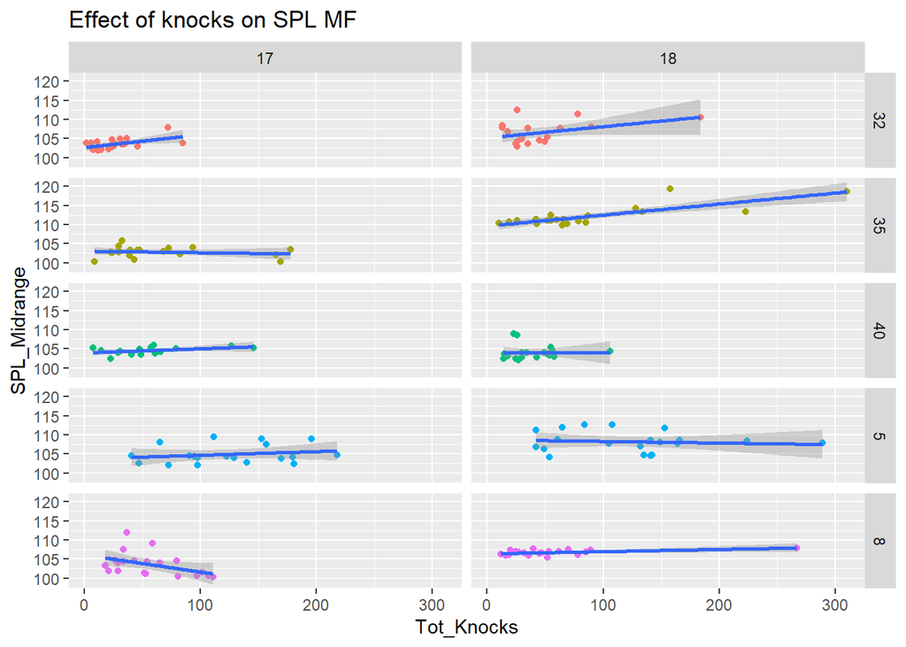

**Breakdown by Site - ACI**

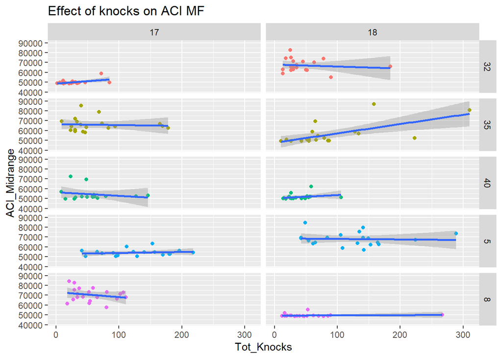

### Mid Frequency - Hourly Breakdown

**Breakdown by Hour - SPL**

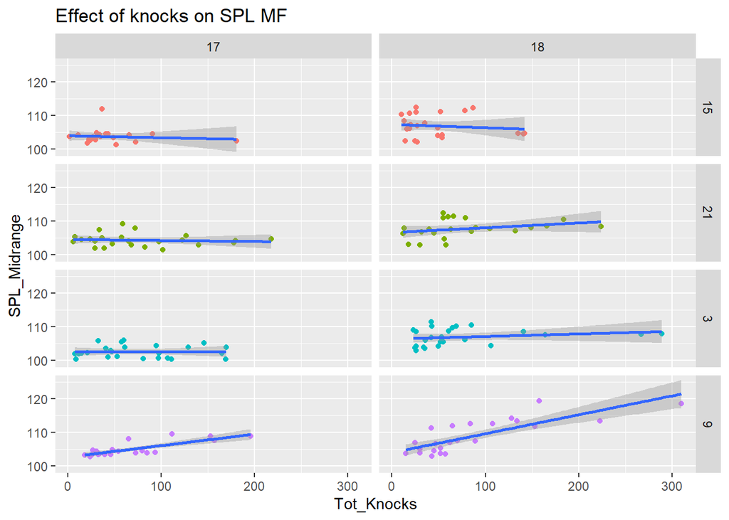

**Breakdown by Hour - ACI**

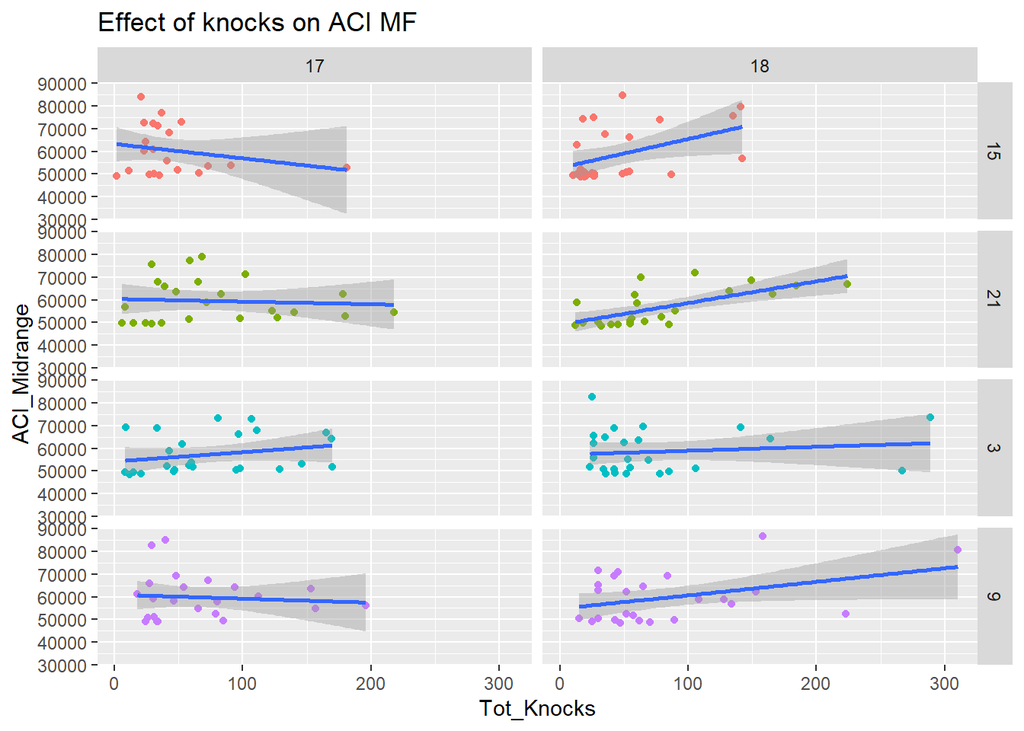

### Mid Frequency Hourly Breakdown (Long Calls)

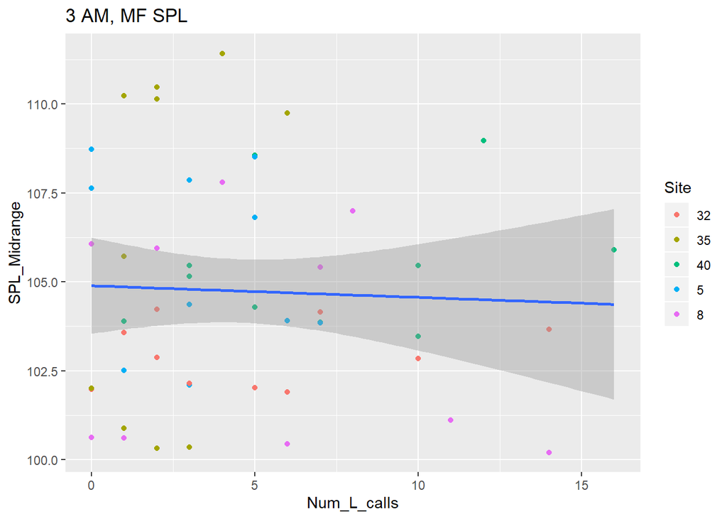

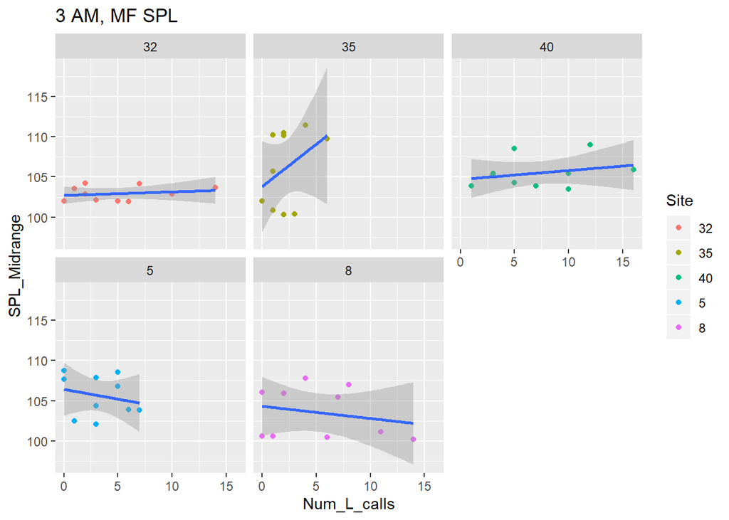

3 AM, long calls don’t seem to explain a great deal of the relationship at any site

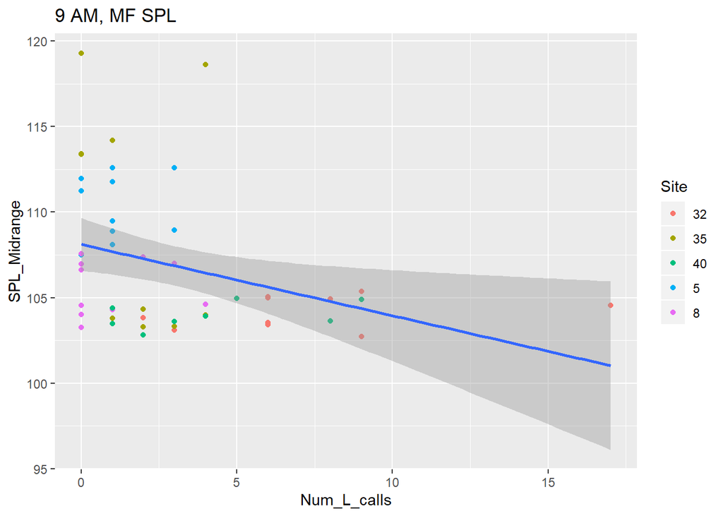

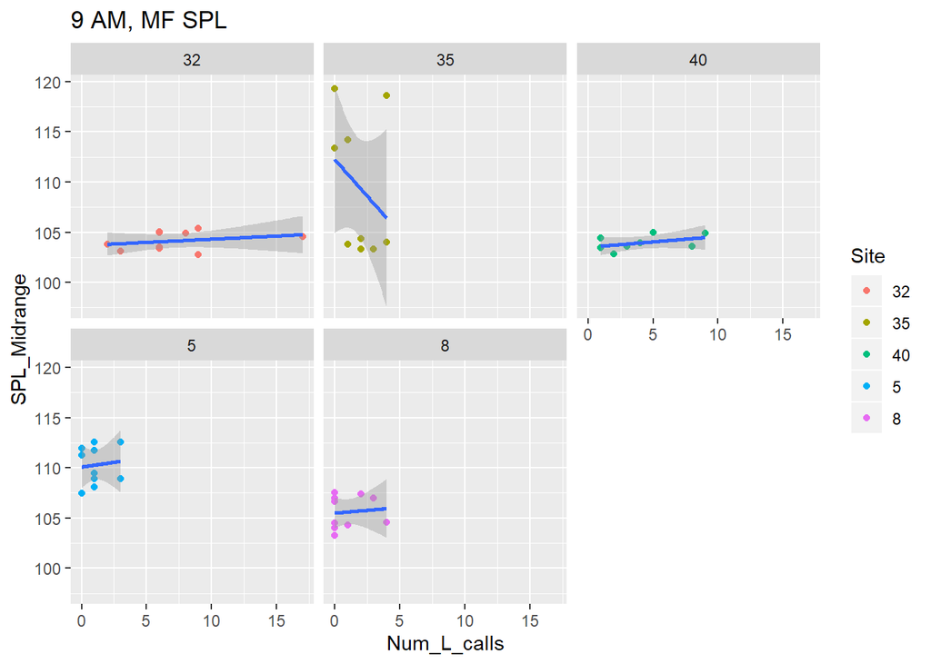

9 AM, long calls don’t seem to explain the relationship at any site

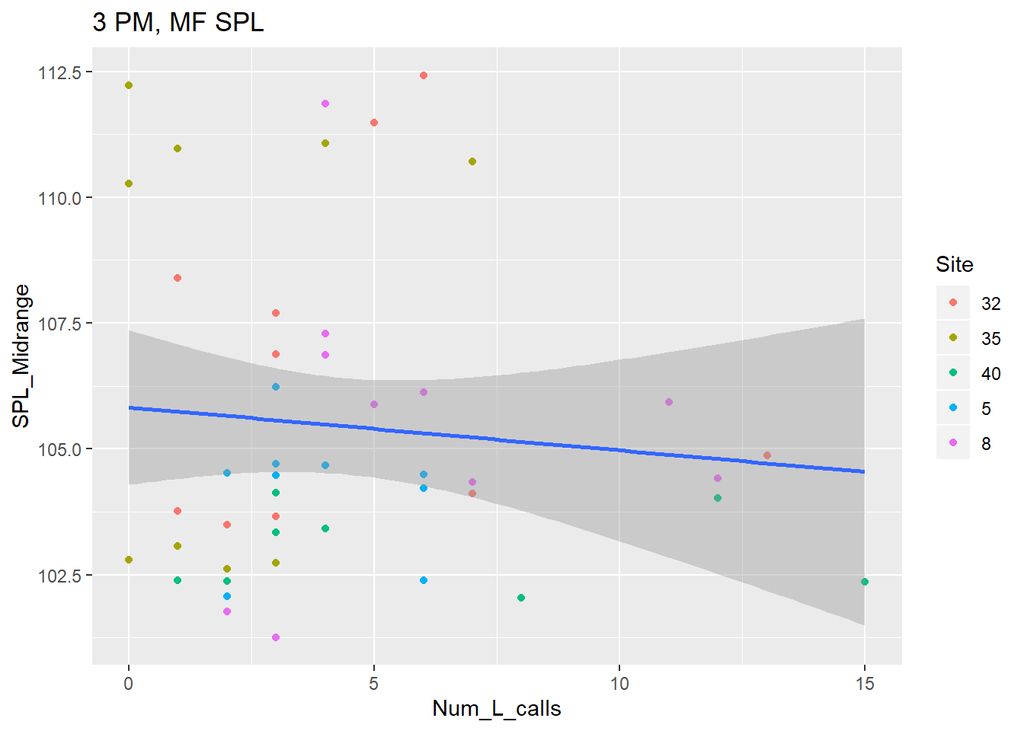

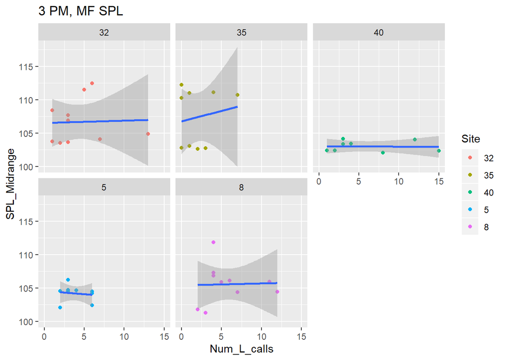

3 PM, long calls don’t seem to explain the relationship

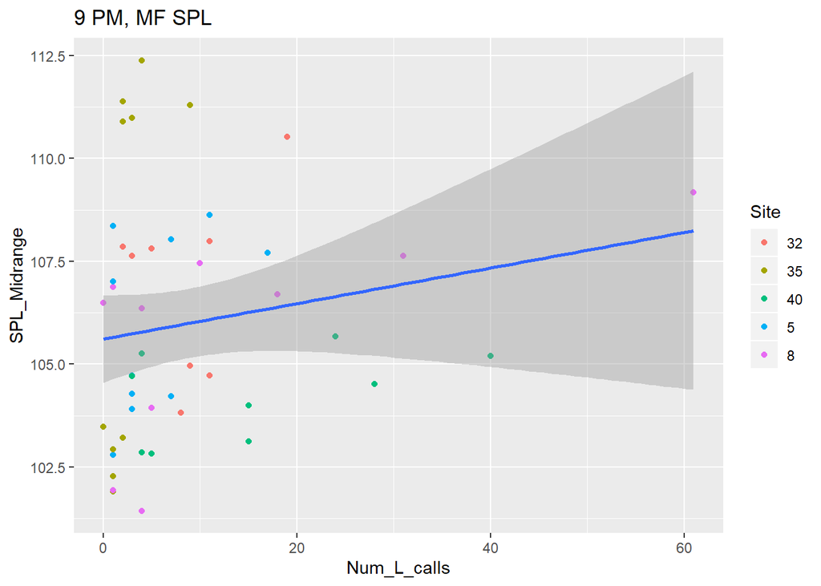

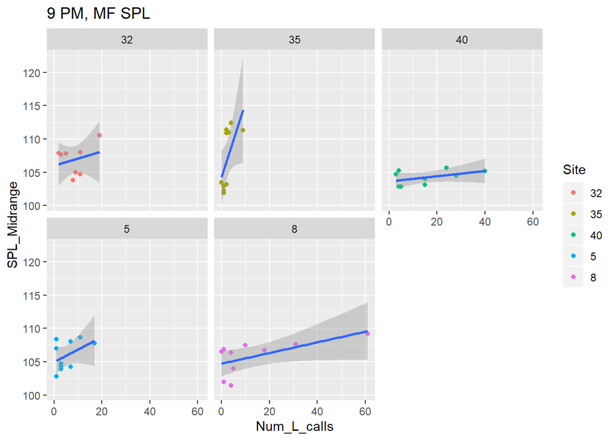

9 PM, long calls don’t seem to explain the relationship

### Mid Frequency Hourly Breakdown (Herbivory)

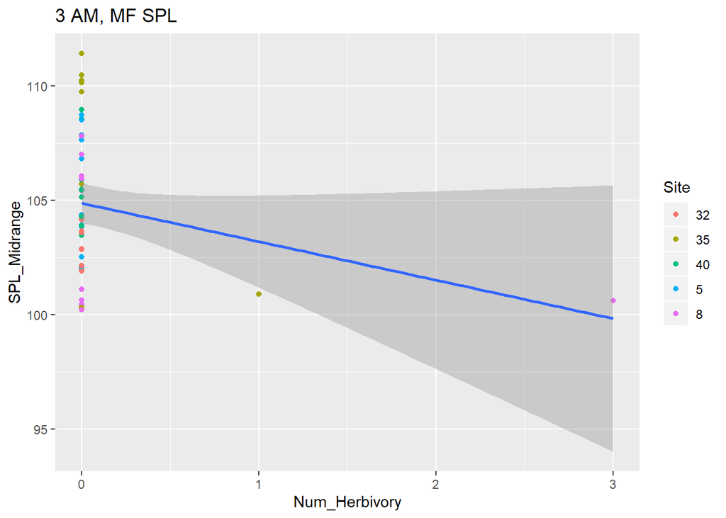

[figure not shown]

3 AM, Extremely low herbivory at all sites. No relationship

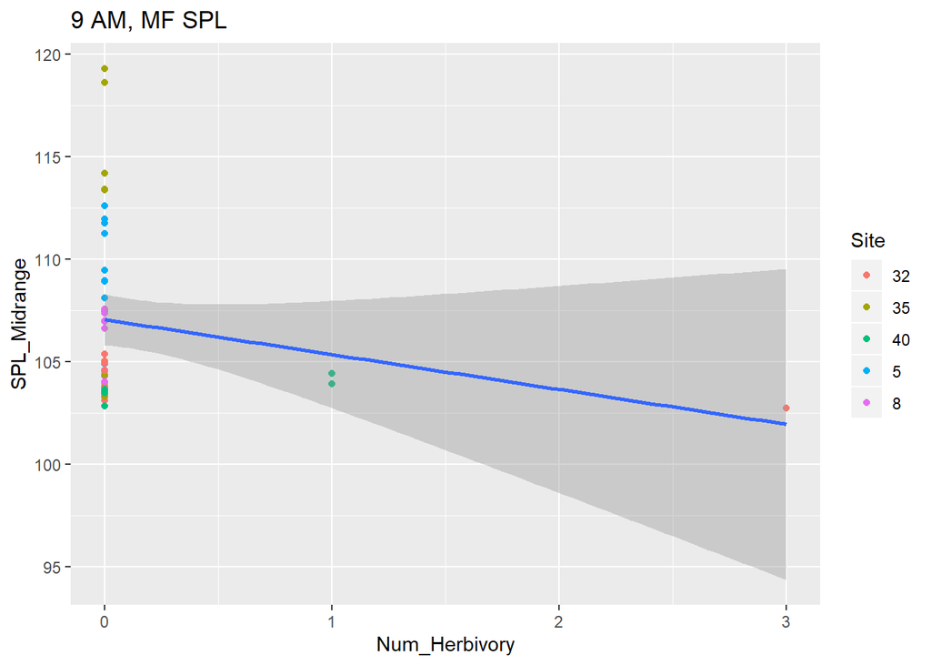

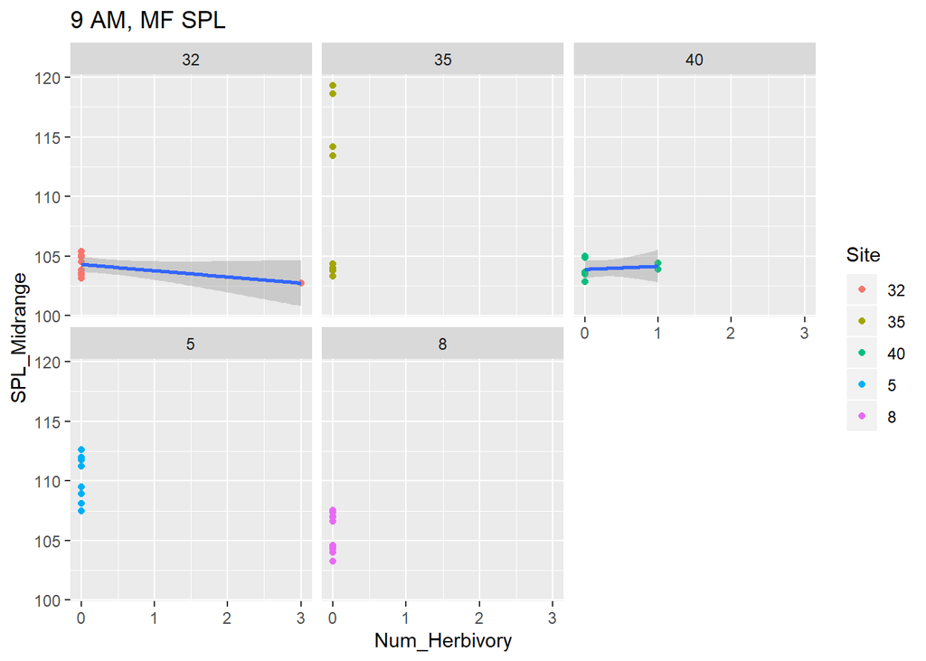

Again, extremely low herbivory, no relationship.

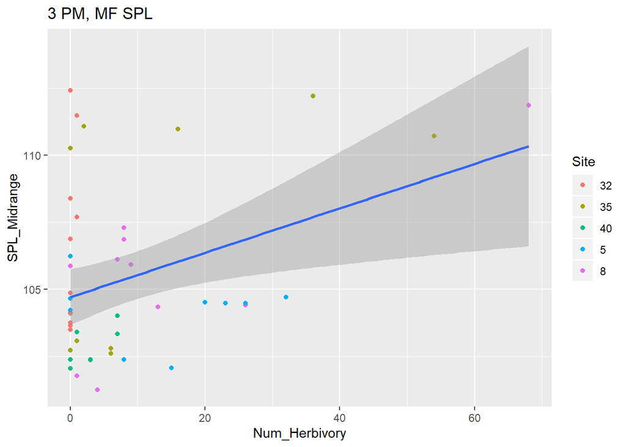

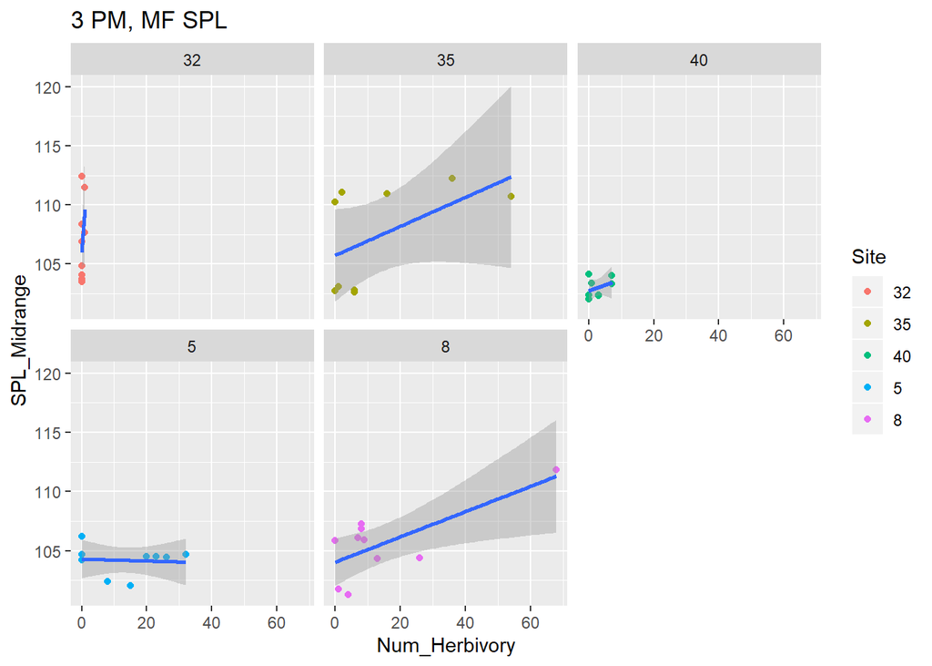

Higher herbivory. Seems like there is a relationship at site 40, 8, and 35.

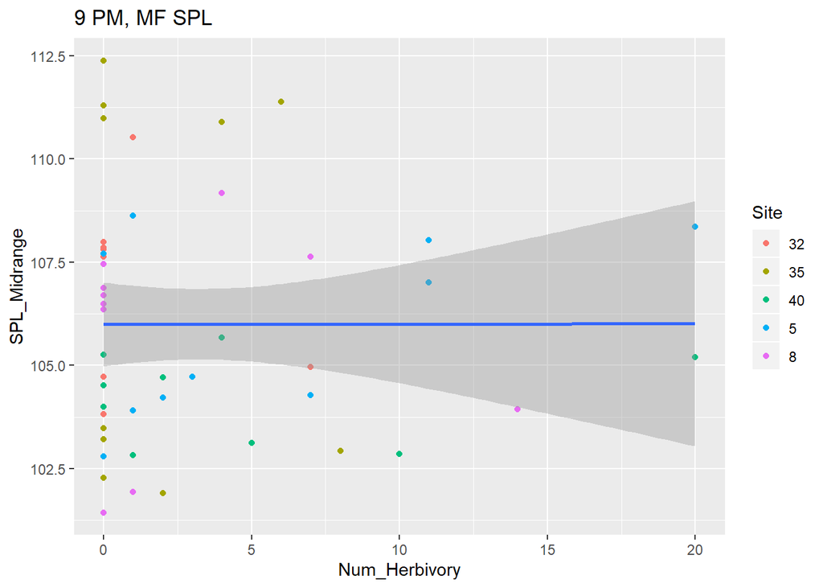

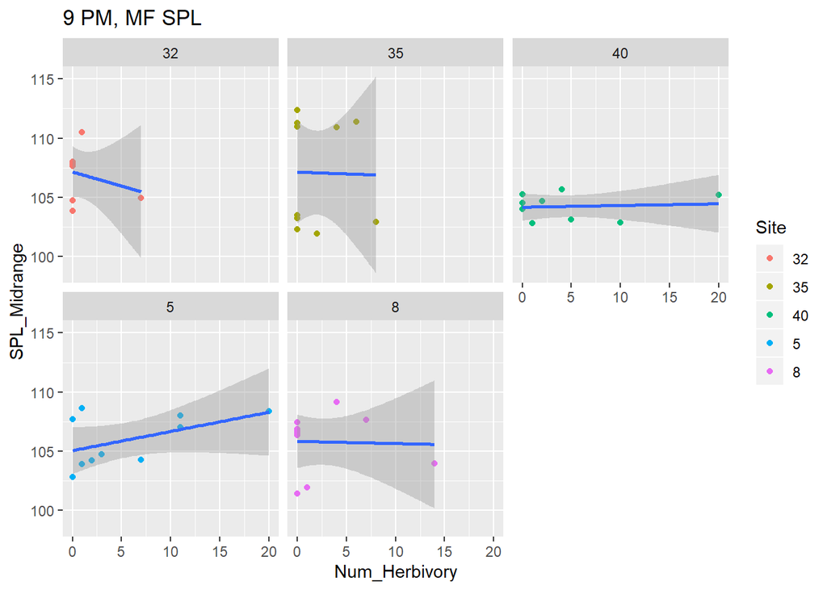

**Summary** Knocks significantly explained SPLMF at sites 35 and 32 and at 9AM.

## High Frequency ACI Model

Distribution looks normal, given what we discussed about the HF SPL distribution

### Maximal Model

```r
#testing time splits for this model to confirm they are the same as SPL HF model
afit.tg1 <- lmer(ACI_HF ~ Snaps*tg + (1|Site) + Year, data = Snap.HFC)
afit.dn1 <- lmer(ACI_HF ~ Snaps*dn + (1|Site) + Year, data = Snap.HFC)
afit.ns1 <- lmer(ACI_HF ~ Snaps*ns + (1|Site) + Year, data = Snap.HFC)
afit.t121 <- lmer(ACI_HF ~ Snaps*t12 + (1|Site) + Year, data = Snap.HFC)



AICc(afit.tg1, afit.dn1, afit.ns1, afit.t121)
```

```
##           df     AICc
## afit.tg1  11 318500.2
## afit.dn1   7 318534.5
## afit.ns1   9 318517.5
## afit.t121  7 318535.6
```

```r
summary(afit.ns1)
```

```
## Linear mixed model fit by REML. t-tests use Satterthwaite's method [
## lmerModLmerTest]
## Formula: ACI_HF ~ Snaps * ns + (1 | Site) + Year
##    Data: Snap.HFC
##
## REML criterion at convergence: 318499.5
##
## Scaled residuals:
##     Min      1Q  Median      3Q     Max
## -2.4291 -0.7243 -0.1895  0.5481  4.4411
##
## Random effects:
##  Groups   Name        Variance Std.Dev.
##  Site     (Intercept)  4330194 2081
##  Residual             26336484 5132
## Number of obs: 15987, groups:  Site, 5
##
## Fixed effects:
##                   Estimate Std. Error         df t value Pr(>|t|)
## (Intercept)      2.422e+05  1.705e+05  1.598e+04   1.421    0.155
## Snaps           -9.079e+00  1.743e+00  1.598e+04  -5.210 1.91e-07 ***
## ns9AM-3PM       -1.664e+02  1.240e+02  1.598e+04  -1.342    0.180
## ns9PM-3AM        1.055e+02  1.081e+02  1.598e+04   0.976    0.329
## Year            -8.819e+01  8.449e+01  1.598e+04  -1.044    0.297
## Snaps:ns9AM-3PM  2.043e-01  2.189e+00  1.598e+04   0.093    0.926
## Snaps:ns9PM-3AM -2.970e-01  1.952e+00  1.598e+04  -0.152    0.879
## ---
## Signif. codes:  0 '***' 0.001 '**' 0.01 '*' 0.05 '.' 0.1 ' ' 1
##
## Correlation of Fixed Effects:
##             (Intr) Snaps  n9AM-3 n9PM-3 Year   S:9AM-
## Snaps        0.021
## ns9AM-3PM    0.011  0.343
## ns9PM-3AM    0.010  0.392  0.624
## Year        -1.000 -0.021 -0.012 -0.010
## Snp:9AM-3PM -0.040 -0.788 -0.164 -0.308  0.040
## Snp:9PM-3AM -0.017 -0.877 -0.297 -0.326  0.017  0.704
```

## High Frequency SPL Model

### Manual Model Selection

Determining which is the best way to group the snaps by time

tg = quarters (00-05, 06-11, 12-17, 18-23) dn = day night (18-05, 6-17) ns = nine cycle (22-03, 04-09, 10-15, 16-21) t12 = my half and half cycle (2140 - 920, 920 - 2140)

```r
fit.rtg <- lmer(SPL_HF ~ Snaps*tg + (1|Site) + Year, data = Snap.HFC)
fit.rdn <- lmer(SPL_HF ~ Snaps*dn + (1|Site) + Year, data = Snap.HFC)
fit.rns <- lmer(SPL_HF ~ Snaps*ns + (1|Site) + Year, data = Snap.HFC)
fit.rt12 <- lmer(SPL_HF ~Snaps*t12 + (1|Site) + Year, data = Snap.HFC)

#models that have a 2 way interaction and time seperately as a factor


AICc(fit.rtg, fit.rdn, fit.rns, fit.rt12)
```

```
##          df     AICc
## fit.rtg  11 71334.97
## fit.rdn   7 74361.55
## fit.rns   9 72857.07
## fit.rt12  7 65738.30
```

### Best Model

Best model was the one that split time at 9:20 and 21:40

Confused about my next steps here

```r
#returned only the three way interaction - so I am going to try some manual selection to see if there is a more parsimonious model

#SPL_HF ~ Snaps + t12 + Site + Snaps:t12 + Snaps:Site + t12:Site


Anova(fit.rt12, type = 3)
```

```
## Analysis of Deviance Table (Type III Wald chisquare tests)
##
## Response: SPL_HF
##                Chisq Df Pr(>Chisq)
## (Intercept) 11516.65  1  < 2.2e-16 ***
## Snaps         120.20  1  < 2.2e-16 ***
## t12         14944.85  1  < 2.2e-16 ***
## Year        11926.88  1  < 2.2e-16 ***
## Snaps:t12      16.98  1  3.778e-05 ***
## ---
## Signif. codes:  0 '***' 0.001 '**' 0.01 '*' 0.05 '.' 0.1 ' ' 1
```

```r
summary(fit.rt12)
```

```
## Linear mixed model fit by REML. t-tests use Satterthwaite's method [
## lmerModLmerTest]
## Formula: SPL_HF ~ Snaps * t12 + (1 | Site) + Year
##    Data: Snap.HFC
##
## REML criterion at convergence: 65724.3
##
## Scaled residuals:
##     Min      1Q  Median      3Q     Max
## -3.1864 -0.6744 -0.0032  0.5999  5.0895
##
## Random effects:
##  Groups   Name        Variance Std.Dev.
##  Site     (Intercept) 1.884    1.373
##  Residual             3.557    1.886
## Number of obs: 15987, groups:  Site, 5
##
## Fixed effects:
##                Estimate Std. Error         df  t value Pr(>|t|)
## (Intercept)  -6.760e+03  6.299e+01  1.598e+04 -107.316  < 2e-16 ***
## Snaps         5.145e-03  4.693e-04  1.598e+04   10.964  < 2e-16 ***
## t12Low       -4.076e+00  3.334e-02  1.598e+04 -122.249  < 2e-16 ***
## Year          3.410e+00  3.122e-02  1.598e+04  109.210  < 2e-16 ***
## Snaps:t12Low -2.492e-03  6.048e-04  1.598e+04   -4.121  3.8e-05 ***
## ---
## Signif. codes:  0 '***' 0.001 '**' 0.01 '*' 0.05 '.' 0.1 ' ' 1
##
## Correlation of Fixed Effects:
##             (Intr) Snaps  t12Low Year
## Snaps        0.087
## t12Low       0.021  0.353
## Year        -1.000 -0.087 -0.022
## Snaps:t12Lw -0.113 -0.793 -0.114  0.113
```

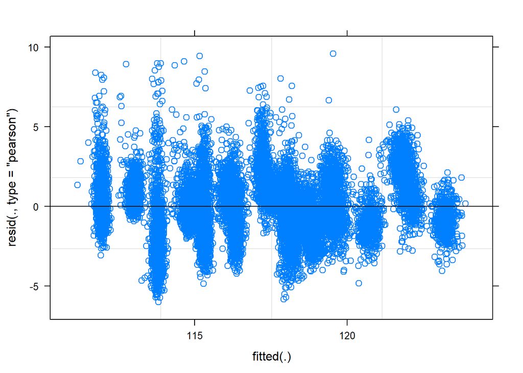

```r
plot(fit.rt12)
```

# Stepwise Models

## SPL HF Model Interpretation

Here I am going to build my models one step at a time, interpretting their results each time before I take the next step and make them more complex.

### Effect of Snaps

```
## Linear mixed model fit by REML. t-tests use Satterthwaite's method [
## lmerModLmerTest]
## Formula: SPL_HF ~ Snaps + (1 | Site) + (1 | Year)
##    Data: Snap.HF
##
## REML criterion at convergence: 76432.1
##
## Scaled residuals:
##     Min      1Q  Median      3Q     Max
## -3.0024 -0.7422  0.0477  0.7447  4.5525
##
## Random effects:
##  Groups   Name        Variance Std.Dev.
##  Site     (Intercept) 2.529    1.590
##  Year     (Intercept) 5.745    2.397
##  Residual             6.956    2.637
## Number of obs: 15987, groups:  Site, 5; Year, 2
##
## Fixed effects:
##              Estimate Std. Error        df t value Pr(>|t|)
## (Intercept) 8.992e+01  1.912e+00 1.607e+00   47.03  0.00163 **
## Snaps       1.895e-02  3.603e-04 1.598e+04   52.60  < 2e-16 ***
## ---
## Signif. codes:  0 '***' 0.001 '**' 0.01 '*' 0.05 '.' 0.1 ' ' 1
##
## Correlation of Fixed Effects:
##       (Intr)
## Snaps -0.275
```

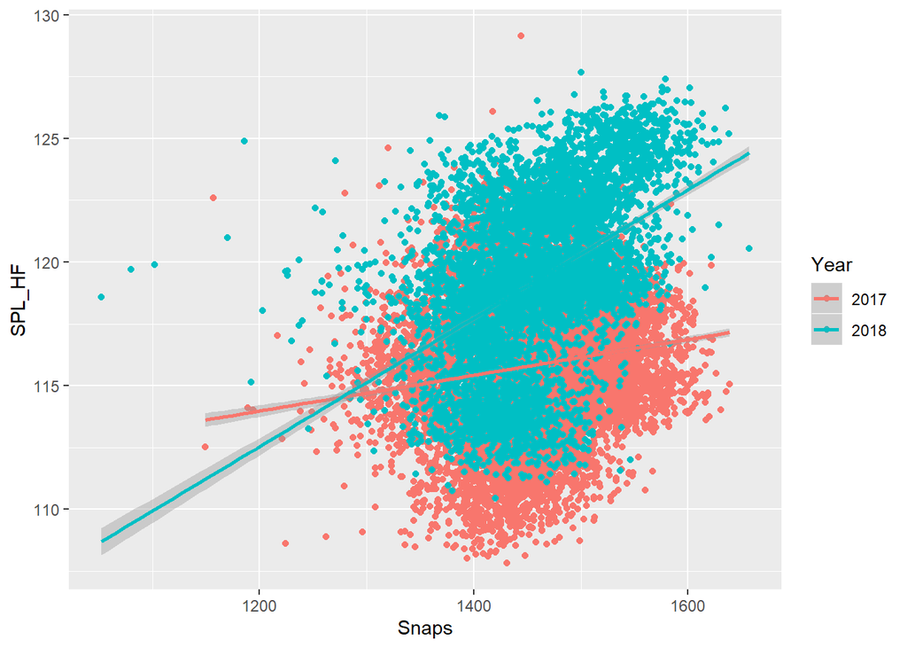

### Effect of Day/Night

```
## Linear mixed model fit by REML. t-tests use Satterthwaite's method [
## lmerModLmerTest]
## Formula: SPL_HF ~ dn + (1 | Site) + (1 | Year)
##    Data: Snap.HF
##
## REML criterion at convergence: 76629.1
##
## Scaled residuals:
##     Min      1Q  Median      3Q     Max
## -3.4073 -0.6388  0.0212  0.6860  3.9732
##
## Random effects:
##  Groups   Name        Variance Std.Dev.
##  Site     (Intercept) 1.739    1.319
##  Year     (Intercept) 5.740    2.396
##  Residual             7.047    2.655
## Number of obs: 15987, groups:  Site, 5; Year, 2
##
## Fixed effects:
##              Estimate Std. Error        df t value Pr(>|t|)
## (Intercept) 1.166e+02  1.794e+00 1.252e+00   64.99  0.00366 **
## dnNight     2.118e+00  4.214e-02 1.598e+04   50.26  < 2e-16 ***
## ---
## Signif. codes:  0 '***' 0.001 '**' 0.01 '*' 0.05 '.' 0.1 ' ' 1
##
## Correlation of Fixed Effects:
##         (Intr)
## dnNight -0.011
```

With only daynight, we see it is significant and nights are 2 dB louder than days.

### Day/Night and Snaps

```
## Linear mixed model fit by REML. t-tests use Satterthwaite's method [
## lmerModLmerTest]
## Formula: SPL_HF ~ Snaps + dn + (1 | Site) + (1 | Year)
##    Data: Snap.HF
##
## REML criterion at convergence: 74432.9
##
## Scaled residuals:
##     Min      1Q  Median      3Q     Max
## -3.4620 -0.6966  0.0238  0.7071  4.1515
##
## Random effects:
##  Groups   Name        Variance Std.Dev.
##  Site     (Intercept) 2.421    1.556
##  Year     (Intercept) 5.797    2.408
##  Residual             6.137    2.477
## Number of obs: 15987, groups:  Site, 5; Year, 2
##
## Fixed effects:
##              Estimate Std. Error        df t value Pr(>|t|)
## (Intercept) 9.243e+01  1.905e+00 1.557e+00   48.51  0.00184 **
## Snaps       1.665e-02  3.420e-04 1.598e+04   48.69  < 2e-16 ***
## dnNight     1.836e+00  3.974e-02 1.598e+04   46.20  < 2e-16 ***
## ---
## Signif. codes:  0 '***' 0.001 '**' 0.01 '*' 0.05 '.' 0.1 ' ' 1
##
## Correlation of Fixed Effects:
##         (Intr) Snaps
## Snaps   -0.260
## dnNight  0.029 -0.145
```

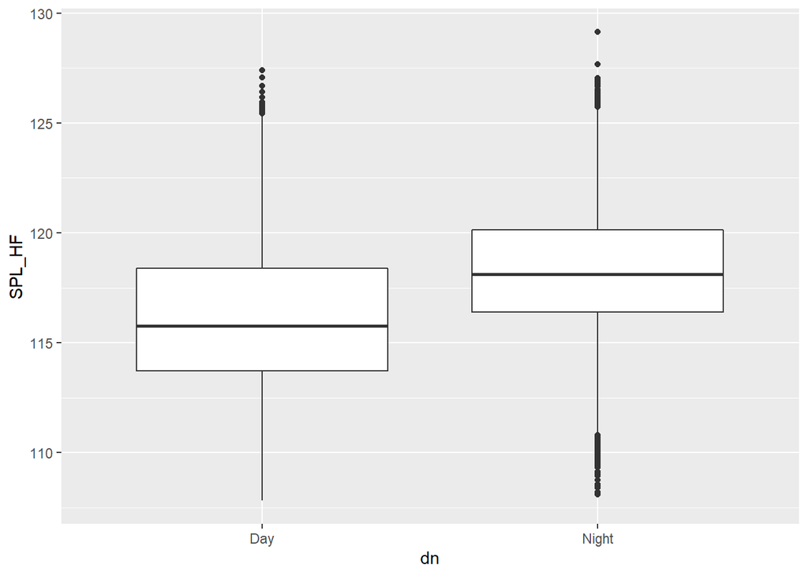

### Day/Night * Snaps

```
## Linear mixed model fit by REML. t-tests use Satterthwaite's method [
## lmerModLmerTest]
## Formula: SPL_HF ~ Snaps * dn + (1 | Site) + (1 | Year)
##    Data: Snap.HF
##
## REML criterion at convergence: 74352.8
##
## Scaled residuals:
##     Min      1Q  Median      3Q     Max
## -3.4252 -0.6976  0.0142  0.7070  4.5889
##
## Random effects:
##  Groups   Name        Variance Std.Dev.
##  Site     (Intercept) 2.435    1.56
##  Year     (Intercept) 5.713    2.39
##  Residual             6.101    2.47
## Number of obs: 15987, groups:  Site, 5; Year, 2
##
## Fixed effects:
##                 Estimate Std. Error         df t value Pr(>|t|)
## (Intercept)    9.648e+01  1.940e+00  1.724e+00  49.721  0.00101 **
## Snaps          1.386e-02  4.471e-04  1.598e+04  31.008  < 2e-16 ***
## dnNight       -7.655e+00  9.845e-01  1.598e+04  -7.775 7.98e-15 ***
## Snaps:dnNight  6.494e-03  6.731e-04  1.598e+04   9.648  < 2e-16 ***
## ---
## Signif. codes:  0 '***' 0.001 '**' 0.01 '*' 0.05 '.' 0.1 ' ' 1
##
## Correlation of Fixed Effects:
##             (Intr) Snaps  dnNght
## Snaps       -0.334
## dnNight     -0.215  0.642
## Snps:dnNght  0.216 -0.647 -0.999
```

### Model Selection

```
##               df     AICc
## simple.model   5 76442.06
## simple.model1  5 76639.06
## simple.model2  6 74444.87
## simple.model4  7 74366.82
```

```
## Linear mixed model fit by REML. t-tests use Satterthwaite's method [
## lmerModLmerTest]
## Formula: SPL_HF ~ Snaps * dn + (1 | Site) + (1 | Year)
##    Data: Snap.HF
##
## REML criterion at convergence: 74352.8
##
## Scaled residuals:
##     Min      1Q  Median      3Q     Max
## -3.4252 -0.6976  0.0142  0.7070  4.5889
##
## Random effects:
##  Groups   Name        Variance Std.Dev.
##  Site     (Intercept) 2.435    1.56
##  Year     (Intercept) 5.713    2.39
##  Residual             6.101    2.47
## Number of obs: 15987, groups:  Site, 5; Year, 2
##
## Fixed effects:
##                 Estimate Std. Error         df t value Pr(>|t|)
## (Intercept)    9.648e+01  1.940e+00  1.724e+00  49.721  0.00101 **
## Snaps          1.386e-02  4.471e-04  1.598e+04  31.008  < 2e-16 ***
## dnNight       -7.655e+00  9.845e-01  1.598e+04  -7.775 7.98e-15 ***
## Snaps:dnNight  6.494e-03  6.731e-04  1.598e+04   9.648  < 2e-16 ***
## ---
## Signif. codes:  0 '***' 0.001 '**' 0.01 '*' 0.05 '.' 0.1 ' ' 1
##
## Correlation of Fixed Effects:
##             (Intr) Snaps  dnNght
## Snaps       -0.334
## dnNight     -0.215  0.642
## Snps:dnNght  0.216 -0.647 -0.999
```

Simple model 4 is the most parsimonious model. This is also my most saturated model which includes the snaps*day/night and the site/year random effect

## ACI HF Model Interpretation

### Step 1 Snaps

```
## Linear mixed model fit by REML. t-tests use Satterthwaite's method [
## lmerModLmerTest]
## Formula: ACI_HF ~ Snaps + (1 | Site) + (1 | Year)
##    Data: Snap.HF
##
## REML criterion at convergence: 318547.2
##
## Scaled residuals:
##     Min      1Q  Median      3Q     Max
## -2.4037 -0.7227 -0.1854  0.5476  4.4113
##
## Random effects:
##  Groups   Name        Variance  Std.Dev.
##  Site     (Intercept) 4.330e+06 2080.77
##  Year     (Intercept) 6.221e+02   24.94
##  Residual             2.634e+07 5132.53
## Number of obs: 15987, groups:  Site, 5; Year, 2
##
## Fixed effects:
##              Estimate Std. Error        df t value Pr(>|t|)
## (Intercept) 77485.941   1383.428    19.443   56.01   <2e-16 ***
## Snaps          -9.046      0.701 15984.892  -12.90   <2e-16 ***
## ---
## Signif. codes:  0 '***' 0.001 '**' 0.01 '*' 0.05 '.' 0.1 ' ' 1
##
## Correlation of Fixed Effects:
##       (Intr)
## Snaps -0.739
```

### Step 1a Day/Night

```
## Linear mixed model fit by REML. t-tests use Satterthwaite's method [
## lmerModLmerTest]
## Formula: ACI_HF ~ dn + (1 | Site) + (1 | Year)
##    Data: Snap.HF
##
## REML criterion at convergence: 318702.9
##
## Scaled residuals:
##     Min      1Q  Median      3Q     Max
## -2.5357 -0.7288 -0.1843  0.5494  4.3934
##
## Random effects:
##  Groups   Name        Variance  Std.Dev.
##  Site     (Intercept) 4.875e+06 2208.018
##  Year     (Intercept) 3.383e+00    1.839
##  Residual             2.662e+07 5159.086
## Number of obs: 15987, groups:  Site, 5; Year, 2
##
## Fixed effects:
##              Estimate Std. Error        df t value Pr(>|t|)
## (Intercept) 64312.719    989.015     3.994  65.027 3.41e-07 ***
## dnNight       -49.272     81.885 15981.001  -0.602    0.547
## ---
## Signif. codes:  0 '***' 0.001 '**' 0.01 '*' 0.05 '.' 0.1 ' ' 1
##
## Correlation of Fixed Effects:
##         (Intr)
## dnNight -0.038
## convergence code: 0
## Model failed to converge with max|grad| = 0.0125051 (tol = 0.002, component 1)
```

Even on its own day/night isn’t significant.

### Step 2 Snaps + Day/Night

```
## Linear mixed model fit by REML. t-tests use Satterthwaite's method [
## lmerModLmerTest]
## Formula: ACI_HF ~ Snaps + dn + (1 | Site) + (1 | Year)
##    Data: Snap.HF
##
## REML criterion at convergence: 318534.9
##
## Scaled residuals:
##     Min      1Q  Median      3Q     Max
## -2.4136 -0.7247 -0.1865  0.5457  4.4209
##
## Random effects:
##  Groups   Name        Variance  Std.Dev.
##  Site     (Intercept) 4.324e+06 2079.33
##  Year     (Intercept) 5.421e+02   23.28
##  Residual             2.634e+07 5132.43
## Number of obs: 15987, groups:  Site, 5; Year, 2
##
## Fixed effects:
##               Estimate Std. Error         df t value Pr(>|t|)
## (Intercept) 77630.8412  1387.5473    19.7234  55.948   <2e-16 ***
## Snaps          -9.1788     0.7086 15983.9994 -12.954   <2e-16 ***
## dnNight       105.8554    82.3394 15980.1562   1.286    0.199
## ---
## Signif. codes:  0 '***' 0.001 '**' 0.01 '*' 0.05 '.' 0.1 ' ' 1
##
## Correlation of Fixed Effects:
##         (Intr) Snaps
## Snaps   -0.741
## dnNight  0.081 -0.146
```

When I include snaps and day/night, the effect size of snaps is relatively the same. Day/night is not significant.

### Step 3 Snaps * Day/Night

```
## Linear mixed model fit by REML. t-tests use Satterthwaite's method [
## lmerModLmerTest]
## Formula: ACI_HF ~ Snaps * dn + (1 | Site) + (1 | Year)
##    Data: Snap.HF
##
## REML criterion at convergence: 318532.4
##
## Scaled residuals:
##     Min      1Q  Median      3Q     Max
## -2.4133 -0.7246 -0.1864  0.5457  4.4208
##
## Random effects:
##  Groups   Name        Variance  Std.Dev.
##  Site     (Intercept) 4.322e+06 2078.86
##  Year     (Intercept) 5.686e+02   23.85
##  Residual             2.634e+07 5132.59
## Number of obs: 15987, groups:  Site, 5; Year, 2
##
## Fixed effects:
##                 Estimate Std. Error         df t value Pr(>|t|)
## (Intercept)    7.765e+04  1.638e+03  3.826e+01  47.420   <2e-16 ***
## Snaps         -9.193e+00  9.280e-01  1.502e+04  -9.906   <2e-16 ***
## dnNight        5.834e+01  2.042e+03  1.314e+04   0.029    0.977
## Snaps:dnNight  3.251e-02  1.396e+00  1.318e+04   0.023    0.981
## ---
## Signif. codes:  0 '***' 0.001 '**' 0.01 '*' 0.05 '.' 0.1 ' ' 1
##
## Correlation of Fixed Effects:
##             (Intr) Snaps  dnNght
## Snaps       -0.822
## dnNight     -0.528  0.641
## Snps:dnNght  0.531 -0.646 -0.999
```

When we introduce the interaction, nothing changes and the interaction isn’t significant nor is day/night. Go figure.

This means that the relationship between snaps and HF ACI doesn’t change between day and night.

### Reduced Model

```
##          df     AICc
## aci.hf    5 318557.2
## aci.hf1a  5 318712.9
## aci.hf2   6 318546.9
## aci.hf4   7 318546.4
```

The most parsimonious model here is aci.hf2, because it is the simplest model.

aci.hf2 includes: Snaps + dn + (1|Site) + (1|Year)

aci.hf4 includes: Snaps*dn + (1|Site) + (1|Year)

### Model Selection

```
##         df     AICc
## aci.hf   5 318557.2
## aci.hf2  6 318546.9
## aci.hf4  7 318546.4
```

```
## Linear mixed model fit by REML. t-tests use Satterthwaite's method [
## lmerModLmerTest]
## Formula: ACI_HF ~ Snaps * dn + (1 | Site) + (1 | Year)
##    Data: Snap.HF
##
## REML criterion at convergence: 318532.4
##
## Scaled residuals:
##     Min      1Q  Median      3Q     Max
## -2.4133 -0.7246 -0.1864  0.5457  4.4208
##
## Random effects:
##  Groups   Name        Variance  Std.Dev.
##  Site     (Intercept) 4.322e+06 2078.86
##  Year     (Intercept) 5.686e+02   23.85
##  Residual             2.634e+07 5132.59
## Number of obs: 15987, groups:  Site, 5; Year, 2
##
## Fixed effects:
##                 Estimate Std. Error         df t value Pr(>|t|)
## (Intercept)    7.765e+04  1.638e+03  3.826e+01  47.420   <2e-16 ***
## Snaps         -9.193e+00  9.280e-01  1.502e+04  -9.906   <2e-16 ***
## dnNight        5.834e+01  2.042e+03  1.314e+04   0.029    0.977
## Snaps:dnNight  3.251e-02  1.396e+00  1.318e+04   0.023    0.981
## ---
## Signif. codes:  0 '***' 0.001 '**' 0.01 '*' 0.05 '.' 0.1 ' ' 1
##
## Correlation of Fixed Effects:
##             (Intr) Snaps  dnNght
## Snaps       -0.822
## dnNight     -0.528  0.641
## Snps:dnNght  0.531 -0.646 -0.999
```

When I compare all of these using AICc I find that the most parsimonious model is aci.hf4 which included Snaps + day/night + site and year as a nested random effect. So day/night must contribute to the model even if it is not significant.

## MF SPL Model Interpretation

### Just One Call Type

```
## Linear mixed model fit by REML. t-tests use Satterthwaite's method [
## lmerModLmerTest]
## Formula: SPL_Midrange ~ Tot_Knocks + (1 | Site) + (1 | Year)
##    Data: AC.DF1Co
##
## REML criterion at convergence: 929.3
##
## Scaled residuals:
##     Min      1Q  Median      3Q     Max
## -2.4538 -0.7475 -0.0461  0.6195  3.4768
##
## Random effects:
##  Groups   Name        Variance Std.Dev.
##  Site     (Intercept) 1.070    1.034
##  Year     (Intercept) 6.648    2.578
##  Residual             6.802    2.608
## Number of obs: 191, groups:  Site, 5; Year, 2
##
## Fixed effects:
##              Estimate Std. Error        df t value Pr(>|t|)
## (Intercept) 1.057e+02  1.890e+00 1.127e+00  55.908 0.007030 **
## Tot_Knocks  1.372e-02  3.894e-03 1.770e+02   3.524 0.000542 ***
## ---
## Signif. codes:  0 '***' 0.001 '**' 0.01 '*' 0.05 '.' 0.1 ' ' 1
##
## Correlation of Fixed Effects:
##            (Intr)
## Tot_Knocks 0.001
```

Model failed to converge?

Might be due to the random effects…

Total knocks are significant

```
## Linear mixed model fit by REML. t-tests use Satterthwaite's method [
## lmerModLmerTest]
## Formula: SPL_Midrange ~ Num_L_calls + (1 | Site) + (1 | Year)
##    Data: AC.DF1Co
##
## REML criterion at convergence: 932.3
##
## Scaled residuals:
##     Min      1Q  Median      3Q     Max
## -1.9763 -0.7343 -0.0446  0.5019  3.8560
##
## Random effects:
##  Groups   Name        Variance Std.Dev.
##  Site     (Intercept) 2.139    1.463
##  Year     (Intercept) 7.186    2.681
##  Residual             6.966    2.639
## Number of obs: 191, groups:  Site, 5; Year, 2
##
## Fixed effects:
##              Estimate Std. Error        df t value Pr(>|t|)
## (Intercept) 105.67472    2.01433   1.21556  52.462  0.00547 **
## Num_L_calls   0.06500    0.02896 186.65590   2.244  0.02598 *
## ---
## Signif. codes:  0 '***' 0.001 '**' 0.01 '*' 0.05 '.' 0.1 ' ' 1
##
## Correlation of Fixed Effects:
##             (Intr)
## Num_L_calls -0.001
## convergence code: 0
## Model failed to converge with max|grad| = 0.0156152 (tol = 0.002, component 1)
```

```
## Linear mixed model fit by REML. t-tests use Satterthwaite's method [
## lmerModLmerTest]
## Formula: SPL_Midrange ~ Num_Herbivory + (1 | Site) + (1 | Year)
##    Data: AC.DF1Co
##
## REML criterion at convergence: 934.9
##
## Scaled residuals:
##     Min      1Q  Median      3Q     Max
## -1.8991 -0.7518 -0.0637  0.5360  3.8445
##
## Random effects:
##  Groups   Name        Variance Std.Dev.
##  Site     (Intercept) 1.563    1.250
##  Year     (Intercept) 6.854    2.618
##  Residual             7.095    2.664
## Number of obs: 191, groups:  Site, 5; Year, 2
##
## Fixed effects:
##                Estimate Std. Error        df t value Pr(>|t|)
## (Intercept)   105.68173    1.94343   1.18565  54.379  0.00584 **
## Num_Herbivory   0.03821    0.02349 185.37861   1.627  0.10548
## ---
## Signif. codes:  0 '***' 0.001 '**' 0.01 '*' 0.05 '.' 0.1 ' ' 1
##
## Correlation of Fixed Effects:
##             (Intr)
## Num_Herbvry 0.000
```

Herbivory is not significant.

### Additive Models

```
## Linear mixed model fit by REML. t-tests use Satterthwaite's method [
## lmerModLmerTest]
## Formula: SPL_Midrange ~ Tot_Knocks + Num_Herbivory + (1 | Site) + (1 |
##     Year)
##    Data: AC.DF1Co
##
## REML criterion at convergence: 931.3
##
## Scaled residuals:
##     Min      1Q  Median      3Q     Max
## -2.4262 -0.7453 -0.0277  0.5867  3.5495
##
## Random effects:
##  Groups   Name        Variance Std.Dev.
##  Site     (Intercept) 1.008    1.004
##  Year     (Intercept) 6.619    2.573
##  Residual             6.709    2.590
## Number of obs: 191, groups:  Site, 5; Year, 2
##
## Fixed effects:
##                Estimate Std. Error        df t value Pr(>|t|)
## (Intercept)   1.057e+02  1.883e+00 1.122e+00  56.124 0.007128 **
## Tot_Knocks    1.424e-02  3.871e-03 1.736e+02   3.679 0.000312 ***
## Num_Herbivory 4.434e-02  2.287e-02 1.854e+02   1.939 0.054027 .
## ---
## Signif. codes:  0 '***' 0.001 '**' 0.01 '*' 0.05 '.' 0.1 ' ' 1
##
## Correlation of Fixed Effects:
##             (Intr) Tt_Knc
## Tot_Knocks  0.001
## Num_Herbvry 0.001  0.066
```

Knocks is significant here, knocks has a tiny effect on MF SPL. Herbivory not significant.

```
## Linear mixed model fit by REML. t-tests use Satterthwaite's method [
## lmerModLmerTest]
## Formula: SPL_Midrange ~ Tot_Knocks + Num_L_calls + (1 | Site) + (1 | Year)
##    Data: AC.DF1Co
##
## REML criterion at convergence: 930.1
##
## Scaled residuals:
##     Min      1Q  Median      3Q     Max
## -2.4959 -0.7195 -0.0586  0.5484  3.5551
##
## Random effects:
##  Groups   Name        Variance Std.Dev.
##  Site     (Intercept) 1.427    1.195
##  Year     (Intercept) 6.837    2.615
##  Residual             6.639    2.577
## Number of obs: 191, groups:  Site, 5; Year, 2
##
## Fixed effects:
##              Estimate Std. Error        df t value Pr(>|t|)
## (Intercept) 1.057e+02  1.934e+00 1.169e+00  54.657 0.006174 **
## Tot_Knocks  1.336e-02  3.874e-03 1.821e+02   3.449 0.000699 ***
## Num_L_calls 6.071e-02  2.823e-02 1.864e+02   2.151 0.032803 *
## ---
## Signif. codes:  0 '***' 0.001 '**' 0.01 '*' 0.05 '.' 0.1 ' ' 1
##
## Correlation of Fixed Effects:
##             (Intr) Tt_Knc
## Tot_Knocks   0.001
## Num_L_calls -0.001 -0.023
```

```
## Linear mixed model fit by REML. t-tests use Satterthwaite's method [
## lmerModLmerTest]
## Formula: SPL_Midrange ~ Tot_Knocks + Num_Herbivory + Num_L_calls + (1 |
##     Site) + (1 | Year)
##    Data: AC.DF1Co
##
## REML criterion at convergence: 932.9
##
## Scaled residuals:
##     Min      1Q  Median      3Q     Max
## -2.4675 -0.7135 -0.0305  0.5894  3.6108
##
## Random effects:
##  Groups   Name        Variance Std.Dev.
##  Site     (Intercept) 1.322    1.150
##  Year     (Intercept) 6.800    2.608
##  Residual             6.578    2.565
## Number of obs: 191, groups:  Site, 5; Year, 2
##
## Fixed effects:
##                Estimate Std. Error        df t value Pr(>|t|)
## (Intercept)   1.057e+02  1.923e+00 1.157e+00  54.951 0.006416 **
## Tot_Knocks    1.389e-02  3.861e-03 1.791e+02   3.596 0.000417 ***
## Num_Herbivory 3.931e-02  2.280e-02 1.843e+02   1.725 0.086293 .
## Num_L_calls   5.511e-02  2.825e-02 1.857e+02   1.951 0.052620 .
## ---
## Signif. codes:  0 '***' 0.001 '**' 0.01 '*' 0.05 '.' 0.1 ' ' 1
##
## Correlation of Fixed Effects:
##             (Intr) Tt_Knc Nm_Hrb
## Tot_Knocks   0.001
## Num_Herbvry  0.001  0.072
## Num_L_calls -0.001 -0.029 -0.107
```

### Adding Hour

```
## Linear mixed model fit by REML. t-tests use Satterthwaite's method [
## lmerModLmerTest]
## Formula: SPL_Midrange ~ Tot_Knocks + Num_Herbivory + Num_L_calls + Hour +
##     (1 | Site) + (1 | Year)
##    Data: AC.DF1Co
##
## REML criterion at convergence: 913.4
##
## Scaled residuals:
##     Min      1Q  Median      3Q     Max
## -2.1875 -0.7171  0.0119  0.6452  3.3049
##
## Random effects:
##  Groups   Name        Variance Std.Dev.
##  Site     (Intercept) 1.371    1.171
##  Year     (Intercept) 6.804    2.609
##  Residual             6.042    2.458
## Number of obs: 191, groups:  Site, 5; Year, 2
##
## Fixed effects:
##                 Estimate Std. Error         df t value Pr(>|t|)
## (Intercept)   105.341601   1.959476   1.247123  53.760 0.004729 **
## Tot_Knocks      0.012961   0.003842 178.936569   3.373 0.000911 ***
## Num_Herbivory   0.049505   0.024271 180.649661   2.040 0.042838 *
## Num_L_calls     0.066645   0.028743 182.552446   2.319 0.021522 *
## Hour21          0.284689   0.563745 179.260295   0.505 0.614181
## Hour3          -0.500087   0.561152 179.238830  -0.891 0.374028
## Hour9           1.610142   0.564306 179.243322   2.853 0.004836 **
## ---
## Signif. codes:  0 '***' 0.001 '**' 0.01 '*' 0.05 '.' 0.1 ' ' 1
##
## Correlation of Fixed Effects:
##             (Intr) Tt_Knc Nm_Hrb Nm_L_c Hour21 Hour3
## Tot_Knocks   0.049
## Num_Herbvry -0.077 -0.043
## Num_L_calls  0.019  0.004 -0.102
## Hour21      -0.154 -0.223  0.285 -0.259
## Hour3       -0.160 -0.222  0.394 -0.047  0.574
## Hour9       -0.157 -0.215  0.384  0.029  0.549  0.607
```

Model failed to converge.

### Adding 1 interaction term

```
## Linear mixed model fit by REML. t-tests use Satterthwaite's method [
## lmerModLmerTest]
## Formula: SPL_Midrange ~ Tot_Knocks + Num_Herbivory + Num_L_calls + Hour +
##     Tot_Knocks:Hour + (1 | Site) + (1 | Year)
##    Data: AC.DF1Co
##
## REML criterion at convergence: 892.7
##
## Scaled residuals:
##      Min       1Q   Median       3Q      Max
## -1.86311 -0.72221 -0.06525  0.62610  2.81233
##
## Random effects:
##  Groups   Name        Variance Std.Dev.
##  Site     (Intercept) 1.042    1.021
##  Year     (Intercept) 6.444    2.539
##  Residual             4.830    2.198
## Number of obs: 191, groups:  Site, 5; Year, 2
##
## Fixed effects:
##                     Estimate Std. Error         df t value Pr(>|t|)
## (Intercept)       104.464726   1.900649   1.237767  54.963  0.00476 **
## Tot_Knocks         -0.018814   0.009275 179.999440  -2.029  0.04398 *
## Num_Herbivory       0.071175   0.022191 177.665989   3.207  0.00159 **
## Num_L_calls         0.061063   0.025748 179.611737   2.372  0.01877 *
## Hour21              1.303889   0.553746 177.289070   2.355  0.01963 *
## Hour3               0.498975   0.553777 177.110889   0.901  0.36879
## Hour9               2.345092   0.556806 177.128860   4.212 4.03e-05 ***
## Tot_Knocks:Hour21   0.018041   0.010376 176.652158   1.739  0.08382 .
## Tot_Knocks:Hour3    0.022449   0.010360 178.358709   2.167  0.03157 *
## Tot_Knocks:Hour9    0.061227   0.010508 178.514015   5.826 2.59e-08 ***
## ---
## Signif. codes:  0 '***' 0.001 '**' 0.01 '*' 0.05 '.' 0.1 ' ' 1
##
## Correlation of Fixed Effects:
##             (Intr) Tt_Knc Nm_Hrb Nm_L_c Hour21 Hour3  Hour9  T_K:H2 T_K:H3
## Tot_Knocks   0.128
## Num_Herbvry -0.093 -0.193
## Num_L_calls  0.015 -0.019 -0.101
## Hour21      -0.177 -0.444  0.340 -0.234
## Hour3       -0.184 -0.466  0.430 -0.035  0.642
## Hour9       -0.181 -0.463  0.421  0.036  0.620  0.673
## Tt_Knck:H21 -0.100 -0.808  0.123  0.049  0.287  0.362  0.363
## Tt_Kncks:H3 -0.111 -0.856  0.191  0.016  0.386  0.375  0.405  0.712
## Tt_Kncks:H9 -0.110 -0.845  0.189  0.002  0.383  0.401  0.365  0.706  0.739
```

### Adding 2nd interaction term

```
## Linear mixed model fit by REML. t-tests use Satterthwaite's method [
## lmerModLmerTest]
## Formula: SPL_Midrange ~ Tot_Knocks + Num_Herbivory + Num_L_calls + Hour +
##     (1 | Site) + (1 | Year) + Tot_Knocks:Hour + Num_Herbivory:Hour
##    Data: AC.DF1Co
##
## REML criterion at convergence: 889.4
##
## Scaled residuals:
##      Min       1Q   Median       3Q      Max
## -1.89715 -0.73559 -0.02868  0.63264  2.84074
##
## Random effects:
##  Groups   Name        Variance Std.Dev.
##  Site     (Intercept) 0.9805   0.9902
##  Year     (Intercept) 6.3489   2.5197
##  Residual             4.7941   2.1895
## Number of obs: 191, groups:  Site, 5; Year, 2
##
## Fixed effects:
##                        Estimate Std. Error         df t value Pr(>|t|)
## (Intercept)          104.365303   1.885409   1.233039  55.354  0.00480 **
## Tot_Knocks            -0.019900   0.009275 176.994884  -2.145  0.03328 *
## Num_Herbivory          0.084611   0.023394 174.815991   3.617  0.00039 ***
## Num_L_calls            0.065644   0.026030 176.553553   2.522  0.01256 *
## Hour21                 1.384652   0.553531 174.403385   2.501  0.01329 *
## Hour3                 -2.064314   2.162225 174.125780  -0.955  0.34104
## Hour9                  2.265405   2.072805 173.609338   1.093  0.27594
## Tot_Knocks:Hour21      0.021992   0.010616 173.923546   2.072  0.03978 *
## Tot_Knocks:Hour3       0.023703   0.010354 175.506379   2.289  0.02325 *
## Tot_Knocks:Hour9       0.062498   0.010542 175.664273   5.928 1.58e-08 ***
## Num_Herbivory:Hour21  -0.119971   0.071396 173.589354  -1.680  0.09469 .
## Num_Herbivory:Hour3   -0.925901   0.714416 173.699220  -1.296  0.19669
## Num_Herbivory:Hour9   -0.079360   0.695021 173.586186  -0.114  0.90922
## ---
## Signif. codes:  0 '***' 0.001 '**' 0.01 '*' 0.05 '.' 0.1 ' ' 1
```

```
##
## Correlation matrix not shown by default, as p = 13 > 12.
## Use print(x, correlation=TRUE)  or
##     vcov(x)        if you need it
```

Adding this new interaction, really nothing changes. None of the levels of the interaction are significant.

```
## boundary (singular) fit: see ?isSingular
```

```
## Linear mixed model fit by REML. t-tests use Satterthwaite's method [
## lmerModLmerTest]
## Formula: SPL_Midrange ~ Tot_Knocks + Num_Herbivory + Num_L_calls + Hour +
##     (1 | Site/Year) + Tot_Knocks:Hour + Num_L_calls:Hour
##    Data: AC.DF1Co
##
## REML criterion at convergence: 830.7
##
## Scaled residuals:
##     Min      1Q  Median      3Q     Max
## -2.0691 -0.5507 -0.0756  0.3670  3.2860
##
## Random effects:
##  Groups    Name        Variance  Std.Dev.
##  Year:Site (Intercept) 6.444e+00 2.539e+00
##  Site      (Intercept) 1.642e-09 4.052e-05
##  Residual              2.957e+00 1.720e+00
## Number of obs: 191, groups:  Year:Site, 10; Site, 5
##
## Fixed effects:
##                      Estimate Std. Error         df t value Pr(>|t|)
## (Intercept)        104.521436   0.871939  11.864972 119.872  < 2e-16 ***
## Tot_Knocks          -0.020839   0.007357 170.744539  -2.833 0.005172 **
## Num_Herbivory        0.053910   0.017784 169.861523   3.031 0.002815 **
## Num_L_calls          0.014005   0.074494 169.571603   0.188 0.851100
## Hour21               1.192995   0.438355 169.366432   2.722 0.007177 **
## Hour3                0.370245   0.441331 169.323378   0.839 0.402692
## Hour9                1.713466   0.473628 169.449439   3.618 0.000392 ***
## Tot_Knocks:Hour21    0.021807   0.008147 169.223605   2.677 0.008166 **
## Tot_Knocks:Hour3     0.025049   0.008166 169.680390   3.068 0.002512 **
## Tot_Knocks:Hour9     0.048233   0.008482 169.973730   5.687 5.54e-08 ***
## Num_L_calls:Hour21   0.049156   0.076710 169.282074   0.641 0.522520
## Num_L_calls:Hour3    0.018169   0.095595 169.171679   0.190 0.849486
## Num_L_calls:Hour9   -0.268359   0.110884 170.009302  -2.420 0.016566 *
## ---
## Signif. codes:  0 '***' 0.001 '**' 0.01 '*' 0.05 '.' 0.1 ' ' 1
```

```
##
## Correlation matrix not shown by default, as p = 13 > 12.
## Use print(x, correlation=TRUE)  or
##     vcov(x)        if you need it
```

```
## convergence code: 0
## boundary (singular) fit: see ?isSingular
```

### Adding 3rd interaction term

```
## Linear mixed model fit by REML. t-tests use Satterthwaite's method [
## lmerModLmerTest]
## Formula: SPL_Midrange ~ Tot_Knocks + Num_Herbivory + Num_L_calls + Hour +
##     (1 | Site) + (1 | Year) + Tot_Knocks:Hour + Num_Herbivory:Hour +
##     Num_L_calls:Hour
##    Data: AC.DF1Co
##
## REML criterion at convergence: 886.9
##
## Scaled residuals:
##      Min       1Q   Median       3Q      Max
## -1.97287 -0.64583 -0.05209  0.53062  2.61707
##
## Random effects:
##  Groups   Name        Variance Std.Dev.
##  Site     (Intercept) 0.9449   0.9721
##  Year     (Intercept) 6.6685   2.5823
##  Residual             4.5750   2.1389
## Number of obs: 191, groups:  Site, 5; Year, 2
##
## Fixed effects:
##                        Estimate Std. Error         df t value Pr(>|t|)
## (Intercept)          104.317611   1.924989   1.204619  54.191  0.00547 **
## Tot_Knocks            -0.019023   0.009069 173.996659  -2.098  0.03738 *
## Num_Herbivory          0.089257   0.022910 172.079754   3.896  0.00014 ***
## Num_L_calls            0.021300   0.092276 172.054018   0.231  0.81772
## Hour21                 1.315479   0.545322 171.428376   2.412  0.01691 *
## Hour3                 -1.953111   2.147130 171.297219  -0.910  0.36429
## Hour9                  2.652145   2.029044 170.486667   1.307  0.19294
## Tot_Knocks:Hour21      0.023025   0.010394 170.950341   2.215  0.02806 *
## Tot_Knocks:Hour3       0.023970   0.010142 172.549368   2.363  0.01922 *
## Tot_Knocks:Hour9       0.058153   0.010404 172.826508   5.589 8.74e-08 ***
## Num_Herbivory:Hour21  -0.137796   0.070231 170.738360  -1.962  0.05138 .
## Num_Herbivory:Hour3   -0.900734   0.707112 170.916713  -1.274  0.20446
## Num_Herbivory:Hour9    0.270518   0.687778 170.208290   0.393  0.69457
## Num_L_calls:Hour21     0.075806   0.095430 171.054451   0.794  0.42808
## Num_L_calls:Hour3      0.018468   0.118591 170.015898   0.156  0.87643
## Num_L_calls:Hour9     -0.273786   0.137250 172.946565  -1.995  0.04764 *
## ---
## Signif. codes:  0 '***' 0.001 '**' 0.01 '*' 0.05 '.' 0.1 ' ' 1
```

```
##
## Correlation matrix not shown by default, as p = 16 > 12.
## Use print(x, correlation=TRUE)  or
##     vcov(x)        if you need it
```

```
## convergence code: 0
## Model failed to converge with max|grad| = 0.00592706 (tol = 0.002, component 1)
```

Model failed to converge.

### Model Selection

```
##            df     AICc
## simple1amf  5 939.6284
## simple1bmf  5 942.5764
## simple1cmf  5 945.2335
## simple2amf  6 943.7420
## simple2bmf  6 942.6005
## simple2cmf  7 947.5236
## simple3mf  10 934.6566
## simple4mf  13 920.7977
## simple6amf 16 924.4898
## simple6bmf 16 865.8122
## simple7mf  19 929.3067
## reducemf   13 920.7977
## reducemf2  16 926.3693
## reducemf3   8 929.6370
## reducemf4  11 921.7608
## reducemf6  12 918.3706
```

```
## Linear mixed model fit by REML. t-tests use Satterthwaite's method [
## lmerModLmerTest]
## Formula:
## SPL_Midrange ~ Tot_Knocks + Hour + Tot_Knocks:Hour + Num_Herbivory +
##     (1 | Site) + (1 | Year)
##    Data: AC.DF1Co
##
## REML criterion at convergence: 892.6
##
## Scaled residuals:
##      Min       1Q   Median       3Q      Max
## -2.00435 -0.69530 -0.08784  0.64481  2.77229
##
## Random effects:
##  Groups   Name        Variance Std.Dev.
##  Site     (Intercept) 0.7178   0.8472
##  Year     (Intercept) 6.2862   2.5072
##  Residual             4.9862   2.2330
## Number of obs: 191, groups:  Site, 5; Year, 2
##
## Fixed effects:
##                     Estimate Std. Error         df t value Pr(>|t|)
## (Intercept)       104.402783   1.863655   1.198634  56.020 0.005374 **
## Tot_Knocks         -0.018103   0.009381 180.497351  -1.930 0.055196 .
## Hour21              1.603556   0.546420 179.087899   2.935 0.003777 **
## Hour3               0.538723   0.561869 178.663913   0.959 0.338953
## Hour9               2.291998   0.564950 178.569859   4.057 7.42e-05 ***
## Num_Herbivory       0.076765   0.022410 178.995446   3.425 0.000761 ***
## Tot_Knocks:Hour21   0.016885   0.010525 178.001069   1.604 0.110422
## Tot_Knocks:Hour3    0.021885   0.010507 180.049618   2.083 0.038676 *
## Tot_Knocks:Hour9    0.061287   0.010657 180.246985   5.751 3.74e-08 ***
## ---
## Signif. codes:  0 '***' 0.001 '**' 0.01 '*' 0.05 '.' 0.1 ' ' 1
##
## Correlation of Fixed Effects:
##             (Intr) Tt_Knc Hour21 Hour3  Hour9  Nm_Hrb T_K:H2 T_K:H3
## Tot_Knocks   0.132
## Hour21      -0.185 -0.460
## Hour3       -0.190 -0.466  0.652
## Hour9       -0.188 -0.461  0.646  0.675
## Num_Herbvry -0.095 -0.197  0.327  0.430  0.427
## Tt_Knck:H21 -0.105 -0.810  0.306  0.364  0.362  0.128
## Tt_Kncks:H3 -0.115 -0.856  0.399  0.374  0.403  0.193  0.713
## Tt_Kncks:H9 -0.113 -0.845  0.393  0.400  0.364  0.190  0.707  0.739
```

reducemf includes Tot_Knocks + Num_Herbivory + Num_L_calls + Hour + Tot_Knocks:Hour + (1|Site)+(1|Year)

reducemf6 includes: Knocks + Hour + Knocks*Hour + Num_Herbivory + (1|Site) + (1|Year)

simple4mf includes Tot_Knocks + Num_Herbivory + Num_L_calls + Hour + Tot_Knocks:Hour + (1|Site)+(1|Year)

## MF ACI Model Interpretation

### Step 1

```
## boundary (singular) fit: see ?isSingular
```

```
## Linear mixed model fit by REML. t-tests use Satterthwaite's method [
## lmerModLmerTest]
## Formula: ACI_Midrange ~ Tot_Knocks + (1 | Site) + (1 | Year)
##    Data: AC.DF1Co
##
## REML criterion at convergence: 4020.6
##
## Scaled residuals:
##     Min      1Q  Median      3Q     Max
## -1.5430 -0.8990 -0.2885  0.7091  2.7119
##
## Random effects:
##  Groups   Name        Variance  Std.Dev.
##  Site     (Intercept) 6.576e+06 2.564e+03
##  Year     (Intercept) 9.752e-03 9.875e-02
##  Residual             8.954e+07 9.462e+03
## Number of obs: 191, groups:  Site, 5; Year, 2
##
## Fixed effects:
##              Estimate Std. Error        df t value Pr(>|t|)
## (Intercept) 58762.338   1335.942     3.754  43.986 3.12e-06 ***
## Tot_Knocks     24.179     13.789   143.181   1.754   0.0816 .
## ---
## Signif. codes:  0 '***' 0.001 '**' 0.01 '*' 0.05 '.' 0.1 ' ' 1
##
## Correlation of Fixed Effects:
##            (Intr)
## Tot_Knocks 0.004
## convergence code: 0
## boundary (singular) fit: see ?isSingular
```

### Step 2, Herbivory or Long Calls

```
## boundary (singular) fit: see ?isSingular
```

```
## Linear mixed model fit by REML. t-tests use Satterthwaite's method [
## lmerModLmerTest]
## Formula: ACI_Midrange ~ Tot_Knocks + Num_Herbivory + (1 | Site) + (1 |
##     Year)
##    Data: AC.DF1Co
##
## REML criterion at convergence: 4008.8
##
## Scaled residuals:
##     Min      1Q  Median      3Q     Max
## -1.5238 -0.8795 -0.2802  0.7005  2.7514
##
## Random effects:
##  Groups   Name        Variance  Std.Dev.
##  Site     (Intercept) 6.125e+06 2474.8732
##  Year     (Intercept) 1.994e-02    0.1412
##  Residual             8.954e+07 9462.6049
## Number of obs: 191, groups:  Site, 5; Year, 2
##
## Fixed effects:
##                Estimate Std. Error        df t value Pr(>|t|)
## (Intercept)   58767.234   1301.748     3.743  45.145 2.92e-06 ***
## Tot_Knocks       25.138     13.771   135.794   1.825   0.0701 .
## Num_Herbivory    91.150     83.271   187.530   1.095   0.2751
## ---
## Signif. codes:  0 '***' 0.001 '**' 0.01 '*' 0.05 '.' 0.1 ' ' 1
##
## Correlation of Fixed Effects:
##             (Intr) Tt_Knc
## Tot_Knocks  0.004
## Num_Herbvry 0.002  0.052
## convergence code: 0
## boundary (singular) fit: see ?isSingular
```

The addition of herbivory does nothing major, the effect size of knocks is even slightly higher.

```
## boundary (singular) fit: see ?isSingular
```

```
## Linear mixed model fit by REML. t-tests use Satterthwaite's method [
## lmerModLmerTest]
## Formula: ACI_Midrange ~ Tot_Knocks + Num_L_calls + (1 | Site) + (1 | Year)
##    Data: AC.DF1Co
##
## REML criterion at convergence: 4008.4
##
## Scaled residuals:
##     Min      1Q  Median      3Q     Max
## -1.5155 -0.9019 -0.2325  0.7009  2.7264
##
## Random effects:
##  Groups   Name        Variance Std.Dev.
##  Site     (Intercept)  8008639 2830
##  Year     (Intercept)        0    0
##  Residual             89201881 9445
## Number of obs: 191, groups:  Site, 5; Year, 2
##
## Fixed effects:
##              Estimate Std. Error        df t value Pr(>|t|)
## (Intercept) 58752.496   1438.600     3.647  40.840 5.48e-06 ***
## Tot_Knocks     23.684     13.860   152.775   1.709   0.0895 .
## Num_L_calls   110.251    102.573   187.798   1.075   0.2838
## ---
## Signif. codes:  0 '***' 0.001 '**' 0.01 '*' 0.05 '.' 0.1 ' ' 1
##
## Correlation of Fixed Effects:
##             (Intr) Tt_Knc
## Tot_Knocks   0.004
## Num_L_calls -0.003 -0.003
## convergence code: 0
## boundary (singular) fit: see ?isSingular
```

The addition of long calls also does nothing here.

### Step 3, Herbivory and Long Calls

```
## boundary (singular) fit: see ?isSingular
```

```
## Linear mixed model fit by REML. t-tests use Satterthwaite's method [
## lmerModLmerTest]
## Formula: ACI_Midrange ~ Tot_Knocks + Num_Herbivory + Num_L_calls + (1 |
##     Site) + (1 | Year)
##    Data: AC.DF1Co
##
## REML criterion at convergence: 3996.8
##
## Scaled residuals:
##     Min      1Q  Median      3Q     Max
## -1.5017 -0.8927 -0.2273  0.6973  2.7513
##
## Random effects:
##  Groups   Name        Variance  Std.Dev.
##  Site     (Intercept) 7.391e+06 2718.6092
##  Year     (Intercept) 2.148e-02    0.1466
##  Residual             8.934e+07 9451.8868
## Number of obs: 191, groups:  Site, 5; Year, 2
##
## Fixed effects:
##                Estimate Std. Error        df t value Pr(>|t|)
## (Intercept)   58758.003   1395.249     3.622  42.113 5.25e-06 ***
## Tot_Knocks       24.664     13.854   144.803   1.780   0.0771 .
## Num_Herbivory    82.143     83.672   186.625   0.982   0.3275
## Num_L_calls      98.513    103.085   186.311   0.956   0.3405
## ---
## Signif. codes:  0 '***' 0.001 '**' 0.01 '*' 0.05 '.' 0.1 ' ' 1
##
## Correlation of Fixed Effects:
##             (Intr) Tt_Knc Nm_Hrb
## Tot_Knocks   0.004
## Num_Herbvry  0.003  0.056
## Num_L_calls -0.004 -0.006 -0.100
## convergence code: 0
## boundary (singular) fit: see ?isSingular
```

With both long calls and herbivory, neither are significant and knocks has roughly the same effect size. ###Step 4, reduced model

```
## boundary (singular) fit: see ?isSingular
```

```
## Linear mixed model fit by REML. t-tests use Satterthwaite's method [
## lmerModLmerTest]
## Formula: ACI_Midrange ~ Tot_Knocks + Hour + (1 | Site) + (1 | Year)
##    Data: AC.DF1Co
##
## REML criterion at convergence: 3968.3
##
## Scaled residuals:
##     Min      1Q  Median      3Q     Max
## -1.5210 -0.8267 -0.2586  0.6791  2.7182
##
## Random effects:
##  Groups   Name        Variance  Std.Dev.
##  Site     (Intercept) 6.087e+06 2467.2086
##  Year     (Intercept) 8.805e-02    0.2967
##  Residual             9.012e+07 9493.0110
## Number of obs: 191, groups:  Site, 5; Year, 2
##
## Fixed effects:
##             Estimate Std. Error       df t value Pr(>|t|)
## (Intercept) 60081.58    1813.40    13.77  33.132 1.59e-14 ***
## Tot_Knocks     28.34      14.27   131.87   1.985   0.0492 *
## Hour21      -2235.86    2019.59   183.34  -1.107   0.2697
## Hour3       -2305.49    1986.36   183.63  -1.161   0.2473
## Hour9        -641.65    2002.90   183.28  -0.320   0.7491
## ---
## Signif. codes:  0 '***' 0.001 '**' 0.01 '*' 0.05 '.' 0.1 ' ' 1
##
## Correlation of Fixed Effects:
##            (Intr) Tt_Knc Hour21 Hour3
## Tot_Knocks  0.183
## Hour21     -0.576 -0.220
## Hour3      -0.584 -0.215  0.536
## Hour9      -0.578 -0.208  0.530  0.537
## convergence code: 0
## boundary (singular) fit: see ?isSingular
```

```
## boundary (singular) fit: see ?isSingular
```

```
## boundary (singular) fit: see ?isSingular
## boundary (singular) fit: see ?isSingular
```

Hour increases knock effect size but is not significant on its own.

### Main Effects Model

```
## boundary (singular) fit: see ?isSingular
```

```
## Linear mixed model fit by REML. t-tests use Satterthwaite's method [
## lmerModLmerTest]
## Formula: ACI_Midrange ~ Tot_Knocks + Num_Herbivory + Num_L_calls + Hour +
##     (1 | Site) + (1 | Year)
##    Data: AC.DF1Co
##
## REML criterion at convergence: 3943.7
##
## Scaled residuals:
##     Min      1Q  Median      3Q     Max
## -1.4901 -0.8073 -0.2461  0.6452  2.6646
##
## Random effects:
##  Groups   Name        Variance Std.Dev.
##  Site     (Intercept)  7647566 2765
##  Year     (Intercept)        0    0
##  Residual             89575717 9464
## Number of obs: 191, groups:  Site, 5; Year, 2
##
## Fixed effects:
##               Estimate Std. Error       df t value Pr(>|t|)
## (Intercept)   59806.54    1984.68    13.77  30.134 5.74e-14 ***
## Tot_Knocks       27.74      14.39   147.34   1.928   0.0558 .
## Num_Herbivory    62.27      93.15   183.04   0.668   0.5047
## Num_L_calls     148.96     109.54   183.28   1.360   0.1755
## Hour21        -2534.45    2168.03   180.59  -1.169   0.2439
## Hour3         -1753.02    2157.69   180.48  -0.812   0.4176
## Hour9           128.68    2170.58   180.50   0.059   0.9528
## ---
## Signif. codes:  0 '***' 0.001 '**' 0.01 '*' 0.05 '.' 0.1 ' ' 1
##
## Correlation of Fixed Effects:
##             (Intr) Tt_Knc Nm_Hrb Nm_L_c Hour21 Hour3
## Tot_Knocks   0.185
## Num_Herbvry -0.294 -0.058
## Num_L_calls  0.076  0.029 -0.097
## Hour21      -0.583 -0.227  0.285 -0.262
## Hour3       -0.606 -0.222  0.396 -0.052  0.574
## Hour9       -0.595 -0.214  0.386  0.026  0.549  0.606
## convergence code: 0
## boundary (singular) fit: see ?isSingular
```

### Saturation Model

```
## boundary (singular) fit: see ?isSingular
```

```
## Linear mixed model fit by REML. t-tests use Satterthwaite's method [
## lmerModLmerTest]
## Formula: ACI_Midrange ~ Tot_Knocks * Hour + Num_Herbivory + Num_L_calls +
##     (1 | Site) + (1 | Year)
##    Data: AC.DF1Co
##
## REML criterion at convergence: 3916.9
##
## Scaled residuals:
##     Min      1Q  Median      3Q     Max
## -1.4653 -0.8091 -0.2447  0.6396  2.6595
##
## Random effects:
##  Groups   Name        Variance Std.Dev.
##  Site     (Intercept)  7690821 2773
##  Year     (Intercept)        0    0
##  Residual             90984751 9539
## Number of obs: 191, groups:  Site, 5; Year, 2
##
## Fixed effects:
##                    Estimate Std. Error        df t value Pr(>|t|)
## (Intercept)       60137.056   2222.657    20.292  27.056   <2e-16 ***
## Tot_Knocks           39.822     39.761   176.823   1.002    0.318
## Hour21            -2905.014   2396.398   179.618  -1.212    0.227
## Hour3             -2069.718   2397.024   179.254  -0.863    0.389
## Hour9              -217.630   2410.428   179.273  -0.090    0.928
## Num_Herbivory        54.474     96.006   180.151   0.567    0.571
## Num_L_calls         149.361    110.625   180.282   1.350    0.179
## Tot_Knocks:Hour21    -7.708     44.973   178.483  -0.171    0.864
## Tot_Knocks:Hour3    -17.520     44.750   180.813  -0.392    0.696
## Tot_Knocks:Hour9    -12.813     45.366   180.932  -0.282    0.778
## ---
## Signif. codes:  0 '***' 0.001 '**' 0.01 '*' 0.05 '.' 0.1 ' ' 1
##
## Correlation of Fixed Effects:
##             (Intr) Tt_Knc Hour21 Hour3  Hour9  Nm_Hrb Nm_L_c T_K:H2 T_K:H3
## Tot_Knocks   0.470
## Hour21      -0.654 -0.442
## Hour3       -0.678 -0.463  0.640
## Hour9       -0.669 -0.459  0.619  0.672
## Num_Herbvry -0.344 -0.198  0.339  0.432  0.423
## Num_L_calls  0.060 -0.009 -0.238 -0.039  0.032 -0.096
## Tt_Knck:H21 -0.370 -0.812  0.285  0.360  0.362  0.123  0.048
## Tt_Kncks:H3 -0.408 -0.857  0.382  0.371  0.401  0.191  0.012  0.713
## Tt_Kncks:H9 -0.404 -0.847  0.380  0.399  0.363  0.189  0.004  0.707  0.738
## convergence code: 0
## boundary (singular) fit: see ?isSingular
```

When we add in the interaction between knocks and hour, nothing is significant.

### Model Selection

```
##            df     AICc
## mf.aci1     5 4030.960
## mf.aci2a    6 4021.217
## mf.aci2b    6 4020.879
## mf.aci3     7 4011.386
## mf.aci4     8 3985.086
## fit.mfaci6 10 3964.947
## fit.mfaci7 13 3944.920
## mf.maxaci  19 3863.086
## mf.acil     5 4028.650
## mf.acih     5 4029.379
## mf.acilh   11 3945.752
## mf.acihh   11 3938.825
```

[output not shown]

mf.maxaci is the best model.

mf.maxaci includes: (Tot_Knocks + Num_L_calls + Num_Herbivory)*Hour + (1|Site) + (1|Year)

but has a singular fit

# Plots_for_Publishing

Plots for use in paper

## High Frequency Plots

Here is a plot using only one site (Site 5)

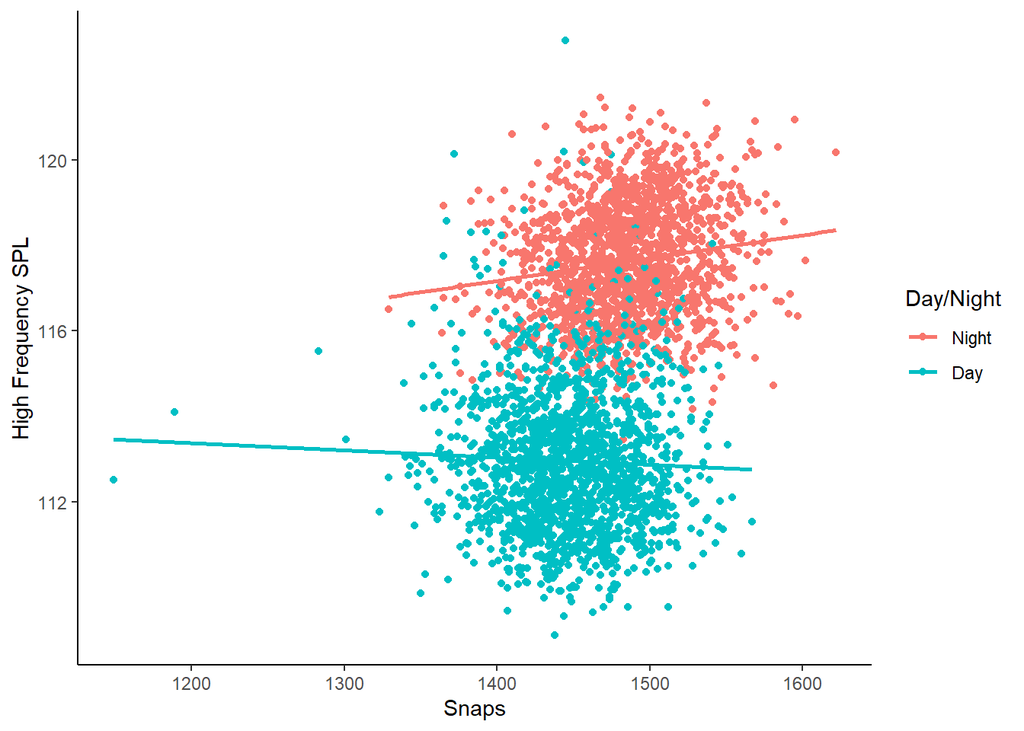

## Mid Frequency Plots

This plot uses ALL data (2017 & 2018) and all sites/hours

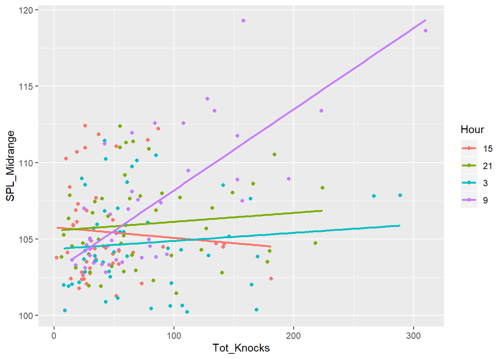

Way too much going on.

Here is a plot that only uses 9am

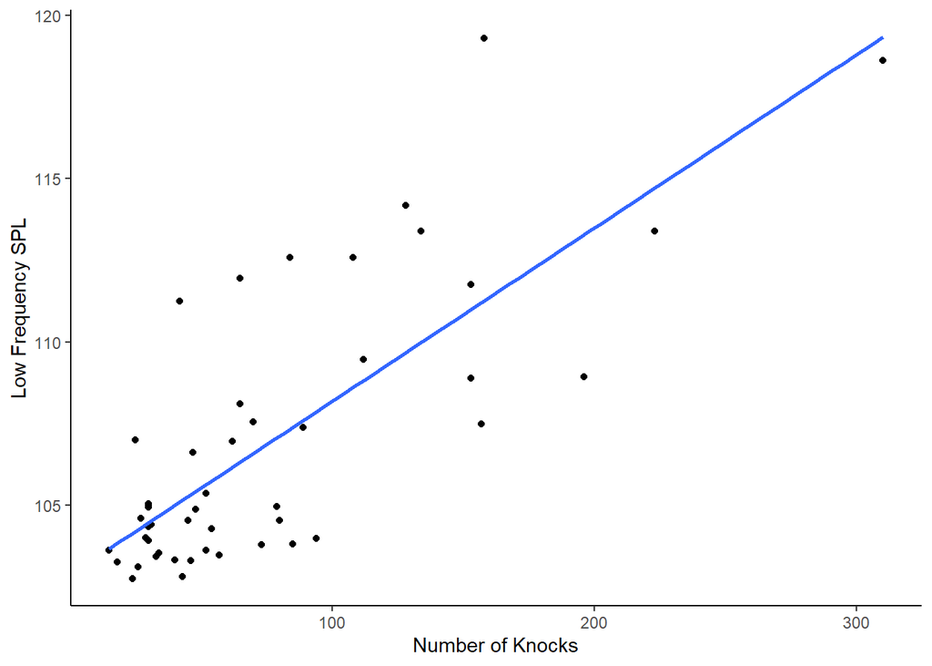

## Diurnal trends Plots

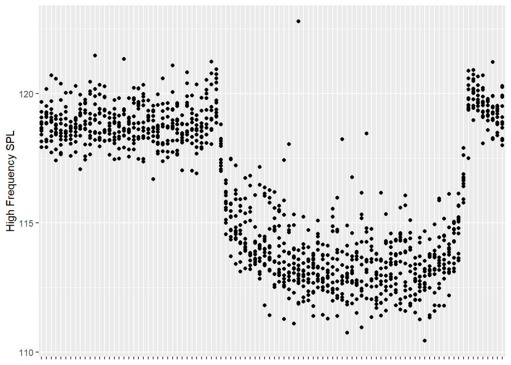

That looks nice!

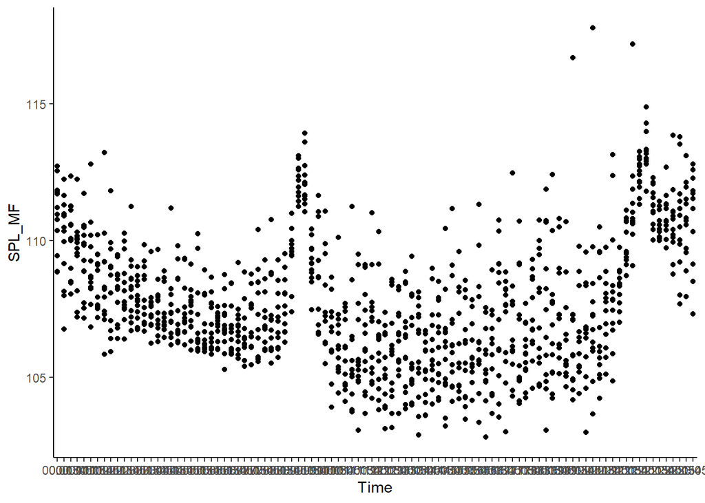

Hey! So does that! Is it not OK for us to use site 5 here because it was the one site that didn’t seem to have a strong relationship at 9 AM?

## Combination Plot

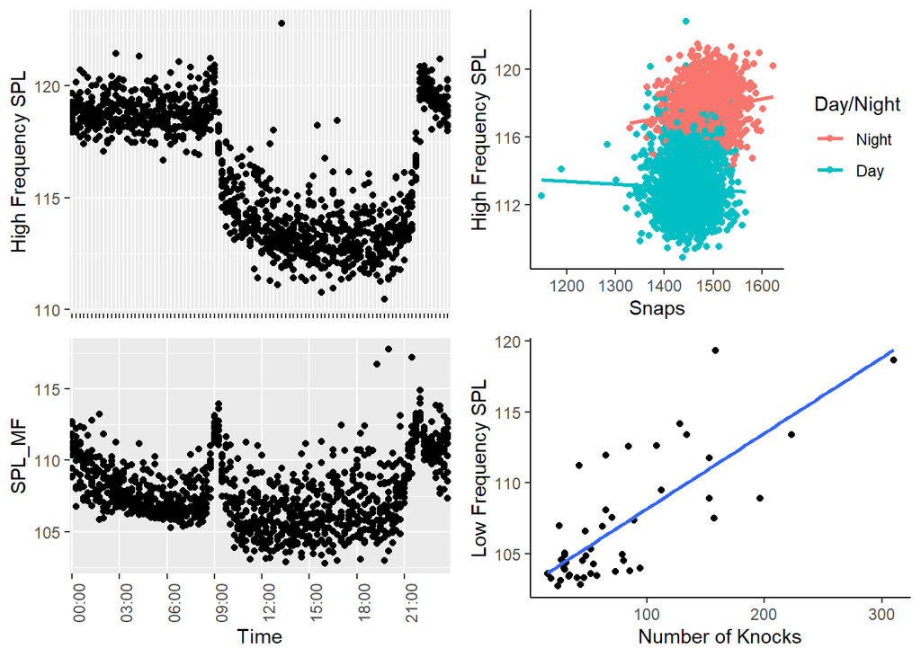

## HF ACI Plots

### Diurnal Plot

[output not shown]

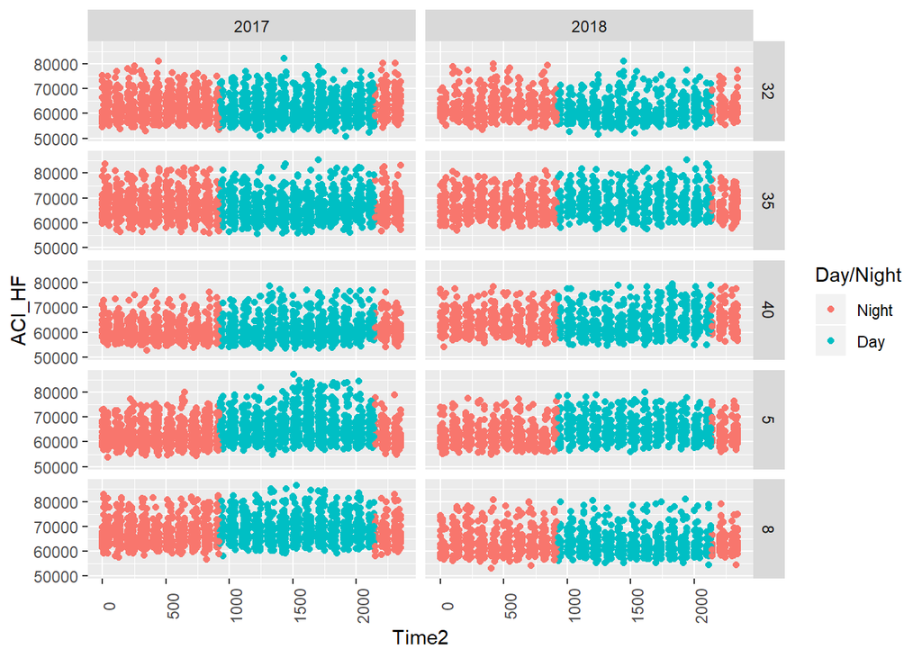

### Point Plot

[output not shown]

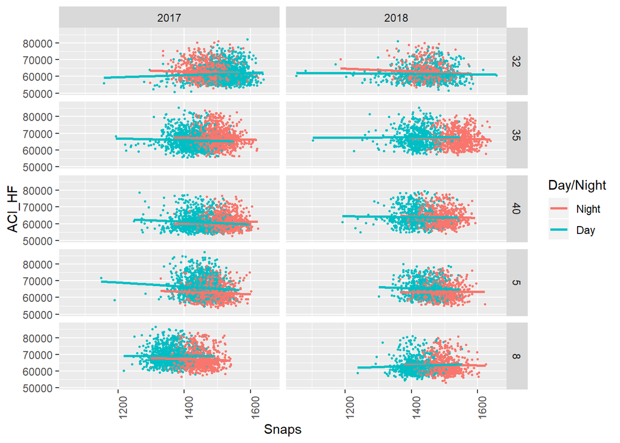

## HF SPL Plots

### Diurnal Plot

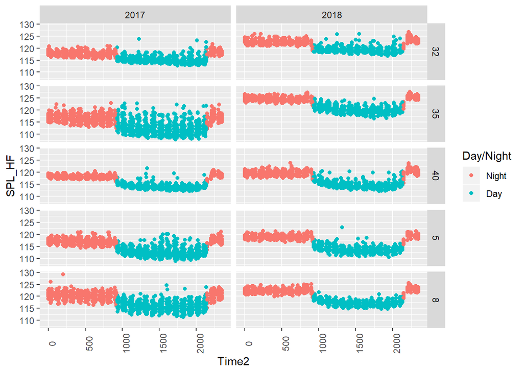

### Point Plot

[output not shown]

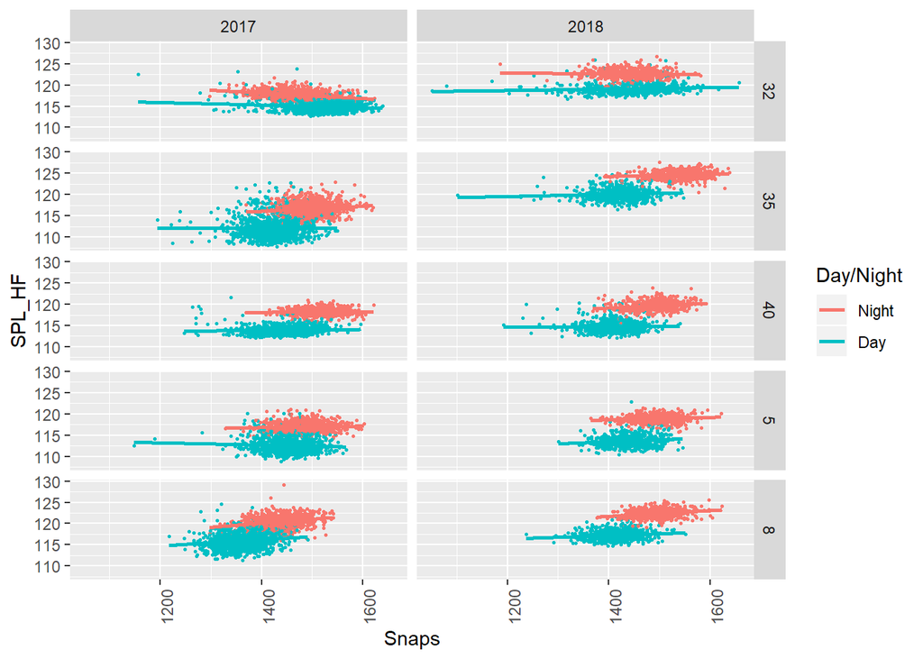

# Supplementary Diurnal Plots

**Acoustics Breakdown** All acoustic metrics (SPL and ACI) are broken down into 2 frequency bands: High Frequency (Frequencies between 1 kHz - 22 kHz) and Mid Frequency (Frequencies between 160 Hz and 1 kHz)

*Note* 2017 had a 10 minute duty cycle with 5 minutes recording while 2018 had a 15 minute duty cycle with 5 minutes recording, so the number of files averages differs between years

## Diurnal Deployment Plots - Supplementary

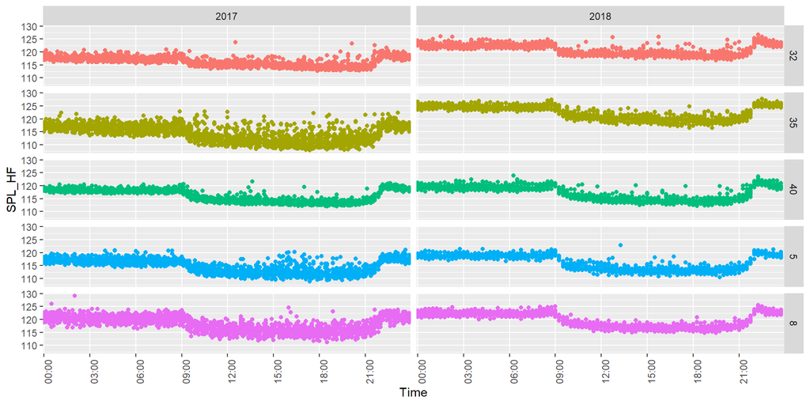

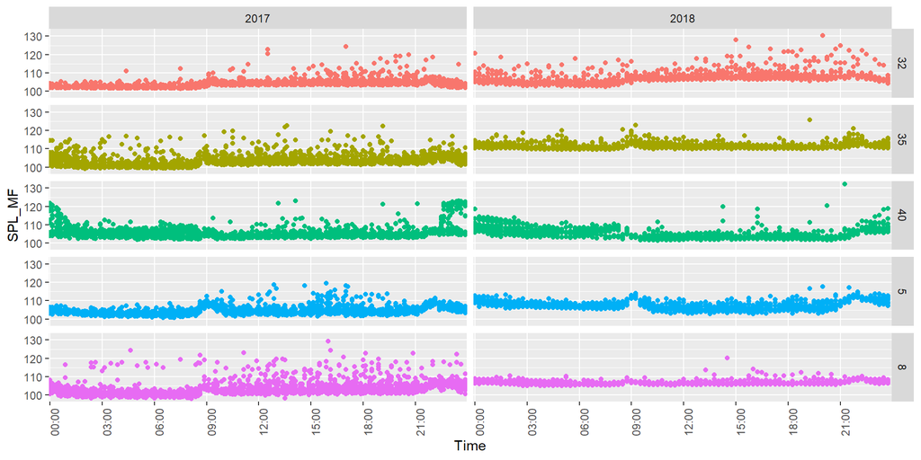

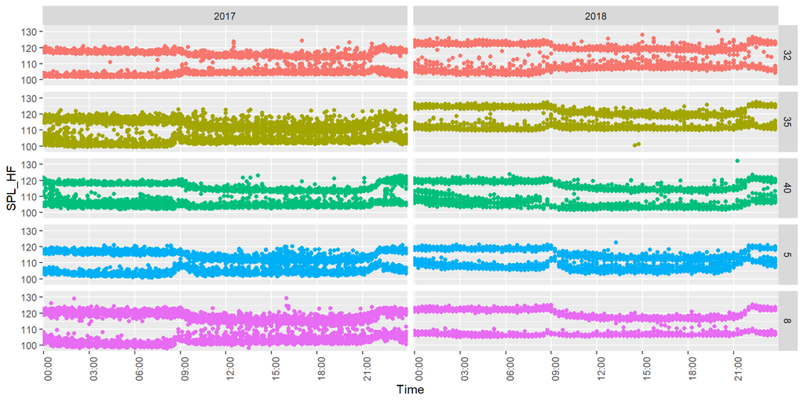

**Total Deployment Plots**

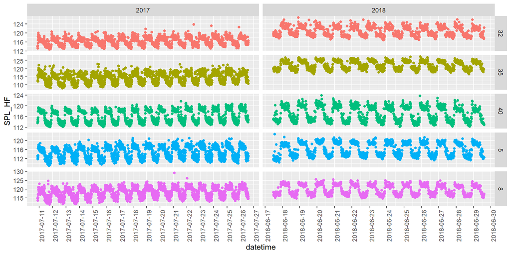

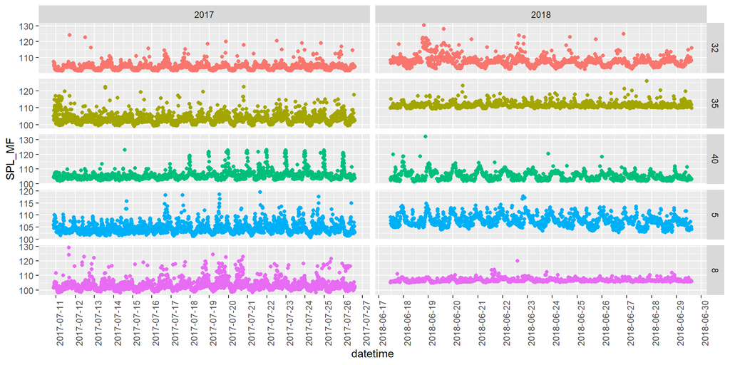

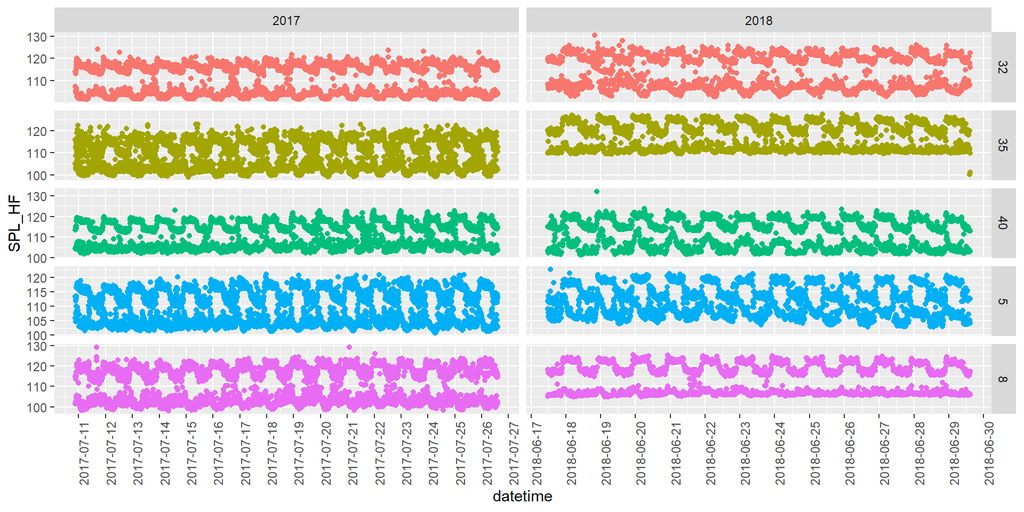